# How connected is the global sovereign credit risk network? - ScienceDirect

## [Journal of Banking & Finance](https://www.sciencedirect.com/journal/journal-of-banking-and-finance)

[Volume 113](https://www.sciencedirect.com/journal/journal-of-banking-and-finance/vol/113/suppl/C), April 2020, 105761

# How connected is the global sovereign credit risk network?☆

https://doi.org/10.1016/j.jbankfin.2020.105761[Get rights and content](https://s100.copyright.com/AppDispatchServlet?publisherName=ELS&contentID=S0378426620300285&orderBeanReset=true)

Full text access

## Abstract

This paper estimates the global network structure of sovereign credit risk by applying the Diebold-Yilmaz connectedness methodology on sovereign [credit default swaps](https://www.sciencedirect.com/topics/economics-econometrics-and-finance/credit-derivative) (SCDSs). The level of credit risk connectedness among sovereigns, which is quite high, is comparable to the connectedness among stock markets and [foreign exchange markets](https://www.sciencedirect.com/topics/economics-econometrics-and-finance/foreign-exchange-market). In the aftermath of the recent financial crises that originated in developed countries, emerging market countries have played a crucial role in the transmission of sovereign credit risk, while developed countries and debt-ridden developing countries have played marginal roles. Secondary regressions show that both trade and capital flows are important determinants of pairwise connectedness across countries. The capital flows became increasingly important after 2013, while the effect of trade flows decreased during the crisis and did not recover afterwards.

## Keywords

Sovereign credit risk

Systemic risk

Network estimation

Lasso

Vector autoregression

Variance decomposition

## JEL classification

F34

G15

C32

G23

## 1. Introduction

The recent financial crises of the [U.S.](https://www.sciencedirect.com/topics/earth-and-planetary-sciences/united-states-of-america) and Europe have underlined the need for additional work to better understand the dynamics of financial crises as well as popularizing terms such as ‘systemic risk’ and ‘financial contagion’ in academic and policy circles.<sup>1</sup> Particularly, debt problems of multiple sovereigns surfaced one after another as in a contagion during the European crisis. If investors and regulators had a better grasp of how and why financial shocks are transmitted across assets, they could react more effectively and minimize potential damage. Therefore, understanding the network structure through which the inital shocks are transmitted can be very valuable.

The literature on financial networks provides good recommendations under simplifying assumptions.<sup>2</sup> Yet more is needed to deal with the complexities of the real world. Developing a model that takes into account all the channels through which the financial assets are connected is not easy because many such channels exist, and some cannot be directly observed. This paper, which takes a different approach, tries to infer the underlying network from market outcomes.

In this paper, we apply the Diebold-Yilmaz connectedness index (see Diebold and Yilmaz 2014) methodology to Sovereign [Credit Default Swap](https://www.sciencedirect.com/topics/economics-econometrics-and-finance/credit-derivative) (SCDS) spreads, which are a proxy for [sovereign default](https://www.sciencedirect.com/topics/economics-econometrics-and-finance/sovereign-default) probabilities. The Diebold-Yilmaz framework relies on the forecast error variance decomposition from a Vector Auto-Regression (VAR) model to obtain an estimate of the underlying network. To measure the strength of the directed edge from variable (in our case, SCDS spread of country) *i* to variable *j*, the model asks, ‘What percent of the forecast error variance of SCDS spread of country *j* is due to shocks to SCDS spread of country *i*?’.

The empirical framework of this paper offers several improvements over existing methods. It utilizes elastic net estimation to overcome the dimensionality problem that arises due to the large number of countries included in the analysis. Thus, rather than choosing “representative” countries from each region, all countries with available data are included in the analysis. Moreover, since most of the previous studies focus on [macroeconomic](https://www.sciencedirect.com/topics/economics-econometrics-and-finance/macroeconomics) fundamentals to explain variation in SCDSs, they cannot work with high-frequency data.<sup>3</sup> Utilizing intra-day data, even daily jumps not necessarily caused by shocks to [macroeconomic](https://www.sciencedirect.com/topics/social-sciences/macroeconomics) fundamentals can be observed in the connectedness of the SCDS spreads. Also, using the Diebold and Yilmaz (2014) framework, it is possible to produce a dynamic network structure through which one can observe either the full network at any point in time, or the dynamic behavior of pairwise connectedness throughout the whole sample period. Finally, the connectedness of SCDSs is displayed in network graphs that can lead to a better understanding of the underlying network structure.

Estimated networks have five main implications. First, the credit risks of countries are highly connected: the aggregate connectedness levels are comparable to the connectedness of foreign exchange or stock markets across countries. Second, the aggregate level of connectedness changes continuously, as do the relative contributions of different sovereigns to it. For example, as of April 2014, shocks in other countries can explain a mere 20% of the variation in the Czech Republic’s SCDS returns. However, this value remained around 90% throughout the heated periods of the European sovereign debt crisis (see Fig. 7). Third, on average, countries at the center of the sovereign credit risk network are emerging markets, while the countries that go through major debt problems (such as Argentina, Greece, and Portugal) play a small role, as do developed countries (such as the U.S. and Japan). Fourth, shocks to other financial assets or indices are quickly reflected in the SCDS spreads. Therefore, adding them to the analysis in a linear model does not increase the explanatory power as long as a large number of sovereigns are controlled for. Fifth, secondary regressions are run to understand the determinants of the credit risk network. Both trade and capital flows are positively correlated with pairwise network links. Moreover, the links among developing countries are stronger than the links among developed countries, even after controlling for trade and capital flows. While the first two findings have been documented by other studies in different contexts, the others are novel contributions of this paper.

This paper adds to the literature on two subjects: the determinants of sovereign credit risk; and the estimation of financial networks. The focal point of the first subject is the relative importance of country-specific and global factors for changes in sovereign credit risk. While one group of studies argues the importance of domestic fundamentals,<sup>4</sup> the other focuses on the importance of global factors.<sup>5</sup> Both groups of studies have common and important implications: sovereign credit risk changes with global factors as well as individual country/government characteristics. Moreover, the relative importance of these variables can change over time and across countries. This paper, which is consistent with these implications, answers a natural question: Given a decomposition of a country’s credit risk determinants into domestic and global factors, how can one further decompose global factors into contributions from different foreign countries?

A second strand connects the literature on the determinants of the SCDS spreads with the literature on the connectedness of financial assets and institutions. For example, Alter and Beyer (2014) show that the systemic contribution of the problematic countries decreased with the implementation of EU and [IMF programs](https://www.sciencedirect.com/topics/economics-econometrics-and-finance/imf-lending). Heinz and Sun (2014) find that [spillovers](https://www.sciencedirect.com/topics/economics-econometrics-and-finance/spillover-effect) between the CESEE (Central, Eastern and Southeastern European) countries and the rest of Europe were relatively small during the European crisis. Cho and Choi (2015) [study Asian](https://www.sciencedirect.com/topics/social-sciences/asian-studies) SCDS markets (7 countries) and find large spillovers except for [Japan](https://www.sciencedirect.com/topics/social-sciences/japan). Many of our findings are consistent with these studies and others in the literature. Yet in contrast to these studies, this paper investigates a wider set of regions and analyzes the interrelations among countries around the world. The increased coverage of countries is particularly important because shocks in one region can easily be attributed to a different region when the first region is not properly represented in the sample. Second, these studies do not focus on the connectedness of the SCDS spread volatilities. In contrast, the current paper studies the network structure of the volatility of the SCDS spreads (as a measure of the uncertainty around credit risk of the sovereigns), as well as the SCDS spreads in order to understand how the two differ from one another.

The remainder of the paper is structured as follows. Section 2 describes the Diebold-Yilmaz connectedness index methodology and provides a brief description of the data set used in our empirical analysis. Section 3 presents full sample results, followed by the time-varying structure of the networks. The implications of the network estimation results are discussed in Section 4. Section 5 analyzes the drivers of the network structure by running secondary regressions. Section 6 concludes the paper.

## 2. Methodology and data

This section provides a brief overview of the empirical approach used to obtain measures of the sovereign credit/default risk network. The aim is to estimate a general network structure, where edges are weighted and directed.<sup>6</sup> Therefore, estimating the network of *N* sovereigns corresponds to estimating weights for $N2−N$ edges.

### 2.1. Diebold-Yilmaz connectedness measures

The Diebold-Yilmaz Connectedness Index (DYCI) method relates forecast error variance decompositions from vector [autoregressions](https://www.sciencedirect.com/topics/economics-econometrics-and-finance/autoregression) to edge weights in networks, providing a network estimate.<sup>7</sup> The variance decomposition matrix gives an intuitively appealing measure of edge weights: What percentage of future uncertainty in variable *i* results from the shocks in variable *j*.

The implementation of the DYCI approach starts with the estimation of an *N*-variable VAR(*p*) model, $xt=∑i=1pϕixt−i+ϵt,$ ϵ<sub>*t*</sub> ~ (0, Σ), which has the following moving-average representation: $xt=∑i=0∞Aiϵt−i$ where $Ai=ϕ1Ai−1+ϕ2Ai−2+…+ϕpAi−p,$ *A*<sub>0</sub> is an identity matrix and *A<sub>i</sub>* is a zero matrix for *i* < 0. Following Diebold and Yilmaz (2014), the ‘generalized variance decomposition’ introduced by Koop et al. (1996), which has the advantage of being invariant to the ordering of variables, is used to obtain the connectedness measures.

In VAR model estimation, the number of parameters to be estimated increases quadratically with the number of variables. To overcome this problem, this paper adopts the Demirer et al. (2018) approach of estimating sparse VAR of [SCDS](https://www.sciencedirect.com/topics/economics-econometrics-and-finance/credit-derivative) returns/volatilities using the elastic net estimator. The estimator minimizes the sum of squared errors under a budget constraint, where the budget is a weighted average of *L*<sub>1</sub> and *L*<sub>2</sub> norms. Intuitively, the estimator shrinks coefficients to zero if estimating them does not substantially reduce the in-sample prediction error. It also introduces bias while reducing the variance of the estimation. For a more detailed explanation of the elastic net estimator, the reader may refer to Appendix A.

#### 2.1.1. Pairwise directional connectedness

Variable *j*’s contribution to variable *i*’s *H*-step-ahead generalized forecast error variance, $θijg(H),$ is calculated as(1)$θijg(H)=σjj−1∑h=0H−1(ei′AhΣej)2∑h=0H−1(ei′AhΣAh′ei),H=1,2,…,$where Σ is the covariance matrix for the error vector ϵ, *σ<sub>jj</sub>* is the [standard deviation](https://www.sciencedirect.com/topics/economics-econometrics-and-finance/measure-of-dispersion) of the error term for the *j*th equation, *A<sub>h</sub>* is *h*-step moving average coefficient matrix, and *e*<sub>*i*</sub> is the selection vector, with one as the *i*th element and zeros otherwise.

Since the shocks are not orthogonal, the entries of each row in the variance decomposition matrix do not add up to 100%. Hence, following Diebold and Yilmaz (2014), all entries of the variance decomposition matrix are divided with the sum of the entries of their respective rows, to obtain:(2)$θ˜ijg(H)=θijg(H)∑j=1Nθijg(H).$where $∑j=1Nθ˜ijg(H)=1$ and $∑i,j=1Nθ˜ijg(H)=N$ follow by construction. $θ˜ijg(H)$ is the ‘directional pairwise connectedness’ from variable *j* to variable *i*: variable *j* generates connectedness to variable *i* if $θ˜ijg(H)$ is positive. In network terminology, $θ˜ijg(H)$ is the estimated size of the edge from node *j* to node *i*.

#### 2.1.2. Aggregate connectedness measures

After calculating the pairwise connectedness measure between variables *i* and *j*, one can look at more aggregate measures; for example, what is the total directional connectedness from variable *i* to all remaining variables, and what is the total directional connectedness to variable *i* from all remaining variables? Following Diebold and Yilmaz (2014), this paper will denote them ‘to connectedness’ and ‘from connectedness’ of variable *i*, respectively.<sup>8</sup> The ‘to connectedness’ of Spain quantifies the percentage that Spain holds in the determination of SCDS spreads (or volatilities) of the whole sample. The ‘from connectedness’ of Spain quantifies what percentage of the SCDS spread (or volatility) of Spain is determined by shocks in other countries in the sample?

The overall importance of shocks that originate in other countries on the determination of the SCDS spreads can be calculated as(3)$C(H)=∑i,j=1i≠jNθ˜ijg(H)∑i,j=1Nθ˜ijg(H)=∑i,j=1i≠jNθ˜ijg(H)N.$This measure is called *system-wide* connectedness, which is simply the average of total directional connectedness measures across countries.<sup>9</sup>

### 2.2. Estimation

In the implementation of the DYCI model, the daily log-returns of SCDS spreads ($log(st/st−1)$), rather than the SCDS spreads themselves (*s<sub>t</sub>*), are chosen as the key variable of interest.<sup>10</sup> The daily SCDS spreads have unit root (Gyntelberg et al. 2013), but the hypothesis of unit root is strongly rejected for the returns.<sup>11</sup> A high return connectedness from sovereign *i* to *j* would imply changes in the credit risk of *i* predict changes in the credit risk of *j*. The second variable of interest is the volatility of the SCDS spreads, which provides a measure of the credit risk uncertainty. A high volatility connectedness from sovereign *i* to *j* would imply changes in uncertainty regarding the credit risk of *i* predict changes in uncertainty regarding the credit risk of *j*. Following Garman and Klass (1980), who use daily (open, high, low, close) spread data, the daily ‘range volatilities’ are estimated.<sup>12</sup> Lastly, regularization/shrinkage methods do not provide simple analytical expressions for (small sample or asymptotic) standard errors of estimates. The bootstrap method is used to generate confidence intervals for connectedness measures.<sup>13</sup>

### 2.3. Graphical display

In the empirical analysis, graphs with as many as 151 nodes and as many as 151<sup>2</sup> edges are presented, once other financial assets are introduced. Presenting the whole network with all the edges would hide the basic patterns in the network structure. Therefore, only the thickest edges are shown in the network graphs. This is solely a visual choice; all network statistics are calculated from the full network.

Throughout the analysis, Gephi, an open-source software for visualizing and analyzing large network graphs, is used to create network graphs. Node size, node color, edge thickness, edge arrow size, edge color, and node locations are used to convey extra and hard-to-spot information about the graph.

*Node Size Indicates Credit Rating*

The Fitch credit ratings of sovereigns determine node sizes. According to these ratings, a sovereign that has a lower credit rating has a bigger node size. This emphasizes countries that have debt problems during a given period.

*Node Color Indicates Total Directional Connectedness “To Others”*

1. [Download: Download high-res image (22KB)](https://ars.els-cdn.com/content/image/1-s2.0-S0378426620300285-gr1_lrg.jpg)
2. [Download: Download full-size image](https://ars.els-cdn.com/content/image/1-s2.0-S0378426620300285-gr1.jpg)

Fig. 1. Color Spectrum.

*Node Location Indicates Strength of Average Pairwise Directional Connectedness*

Locations of the nodes are determined by the ForceAtlas2 algorithm of Jacomy et al. (2014), as implemented in Gephi. In the ForceAtlas2 algorithm, the nodes repel each other but the edges attract the nodes they connect. The algorithm finds a steady state in which for every pair of nodes repelling and attracting forces exactly balance one another as determined by the average pairwise directional connectedness between the two nodes. In the steady-state, nodes that have higher pairwise directional connectedness values are expected to be closer to each other.

*Edge Thickness Indicates Average Pairwise Directional Connectedness*

Edge color is lighter for the weakest links and the same for all the others. Since average pairwise directional connectedness is represented by edge thickness, edge color is employed to attain clearer visuals.

*Edge Arrow Size Indicates Pairwise Directional Connectedness*

The size of the edge arrow from node *i* to node *j* increases with the pairwise directional connectedness from node *i* to node *j*.

### 2.4. Data

Daily 5YR spread data is used in the main empirical analysis. Missing returns are set to 0 and missing volatilities are interpolated whenever the missing segment of the series is not more than 8 consecutive days. However, if the missing data segment is longer than 8 consecutive days, the sovereign is dropped from the sample. A lack of data availability for consecutive weeks is common for some sovereigns, especially in the case of SCDS volatilities. There is a trade-off between the number of sovereigns in the sample and the length of the sample period. Taking this trade-off into account, we use different sample periods for different analyses in the study.

The main full sample and rolling sample window analyses are undertaken using data from Bloomberg for 38 countries from February 2009 to April 2014. The paper also provides some analysis with a smaller sample of data from Markit in 26 countries, which ranges from September 2007 to May 2019.<sup>14</sup> In daily network estimations, all countries that have available data in that window (150 days) are used with a maximum of 54 countries. For instance, 50 sovereign SCDS returns are included in the network estimation of the window ending May 26, 2010, as those 50 particular sovereigns have full data available for the previous 150 days while the other four sovereigns do not.

## 3. Network estimation results

### 3.1. Full-Sample networks: returns vs. volatilities

In this section, the whole sample period is used to estimate an ‘average’ network of the entities. Fig. 2(a) and (b) present the full sample SCDS return and volatility connectedness graphs, respectively.<sup>15</sup> Fig. 2(a) shows that sovereigns are divided into two big clusters that represent developed and the developing countries.<sup>16</sup> The connectedness across the two clusters is quite weak, as shown by thin pairwise edges between the members of the two clusters. Japan stands further away from other developed countries and exhibits some weak connections with developing countries.<sup>17</sup>

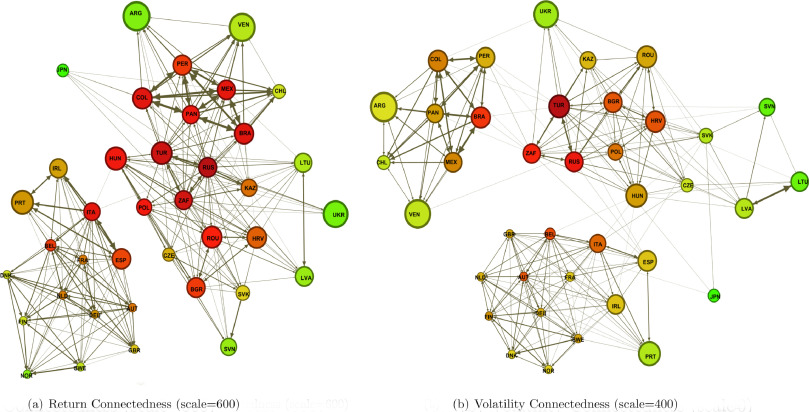

1. [Download: Download high-res image (1MB)](https://ars.els-cdn.com/content/image/1-s2.0-S0378426620300285-gr2_lrg.jpg)
2. [Download: Download full-size image](https://ars.els-cdn.com/content/image/1-s2.0-S0378426620300285-gr2.jpg)

Fig. 2. Sovereign CDS Network, 2009–2014 (25% of the edges visible) See Appendix C for the list of countries included and Section 2.3 for the graphical display method used.

Portugal, Ireland, Italy, and Spain stand tightly connected in the upper region of their cluster. Russia, [South Africa](https://www.sciencedirect.com/topics/earth-and-planetary-sciences/republic-of-south-africa), and Turkey generate the highest connectedness to others as well as the highest pairwise connectedness to each other. The CESEE countries are mostly located around the periphery of the developing country cluster and are not tightly connected with the developed side of the EU. This result supports the Heinz and Sun (2014)’s observation that [spillovers](https://www.sciencedirect.com/topics/economics-econometrics-and-finance/spillover-effect) between the EU periphery and CESEE countries were low during the sovereign debt crisis. The most tightly connected countries in the whole graph are Brazil, [Mexico](https://www.sciencedirect.com/topics/social-sciences/mexico), Panama, Peru, and Colombia.

Distinctions between the network structures of SCDS spread returns in Fig. 2(a) and volatilities in Fig. 2(b) are visible. There seem to be three main clusters in the volatility connectedness graph, with weaker links between them, compared to the return graph.<sup>18</sup> While Latin American countries seem to be highly connected to the rest of the developing countries in the network of returns, they stand apart in the network of volatilities.

### 3.2. Dynamic index estimation

The full sample analysis only produces a measure of the average network during the sample period. However, the relative and absolute importance of sovereigns in transmitting shocks can change over time. This paper uses a simple rolling window analysis to capture these dynamics. The model is estimated separately for each date, using only the previous *T* observations, where *T* is the fixed rolling window size. To achieve a balance between trend spotting and sample size, the window size is chosen to be 150 days, or roughly 7 months.<sup>19</sup>

#### 3.2.1. Dynamic evolution of SCDS return connectedness

Fig. 3 presents the system-wide connectedness measure for SCDS returns. The green line is the index for the sample of 38 sovereigns from February 2009 to April 2014 and, thus, it is the main focus of this section.<sup>20</sup> During relatively problematic periods, the importance of global factors increases.<sup>21</sup> While there are several increases in the index over this period, two significant jumps in the index can be distinguished in the graph that correspond to important turning points.

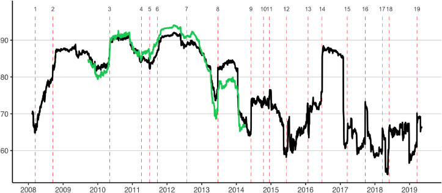

1. [Download: Download high-res image (377KB)](https://ars.els-cdn.com/content/image/1-s2.0-S0378426620300285-gr3_lrg.jpg)
2. [Download: Download full-size image](https://ars.els-cdn.com/content/image/1-s2.0-S0378426620300285-gr3.jpg)

Fig. 3. System-wide Return Connectedness and Important Events Over Time: Comparing 38- and 26-country Samples. Timetable for important events: **1)** J.P. Morgan takes over Bear Stearns, the troubled investment bank (03/16/08). **2)** Lehman Brothers goes bankrupt (09/15/08). **3)** U.S. stock market flash crash and first Greek [austerity](https://www.sciencedirect.com/topics/economics-econometrics-and-finance/fiscal-consolidation) plan (05/06/10). **4)** Portuguese government calls on EU for bailout (04/06/11). **5)** Greek Parliament approval of the second austerity bill followed by violent protests (06/29/11). EU postpones decision on the bailout plan. Borrowing costs for Italy and Spain spiked. (07/03/11). **6)** Fed launches Operation Twist (09/21/11). **7)** Draghi makes the famous “Whatever It Takes” speech (07/26/12). **8)** Bernanke announces Fed’s “Tapering” decision (06/20/13). **9)** ECB policy rate breaking through the [zero lower bound](https://www.sciencedirect.com/topics/economics-econometrics-and-finance/low-interest-rate-policy) for the first time (06/05/14). **10)** Flash Crash in the U.S. Treasury bill market (10/15/14). **11)** EU and U.S. imposed sanctions on Russian-occupied Crimea (12/19/14). **12)** Chinese stock market turbulence begins with the popping of the stock market bubble (06/12/15). **13)** CoCo Bond crisis spreads to other EU banks as the Deutsche Bank revises its 2015 losses upwards (01/28/16). **14)** [Brexit](https://www.sciencedirect.com/topics/social-sciences/brexit): UK decides to leave EU (06/23/16). **15)** Fed rate hike, signals more to come (03/15/17). **16)** Yellen announces “The Great Unwinding”, Fed starts to reduce bond holdings in Oct. 2017 (09/20/17). **17)** Fed hikes rate (in Chairman Powell’s first meeting) along with future rate hike signals (03/21), Trump’s decision to impose tariffs on imports from China hits global markets (03/22/18). **18)** Italy fear spreads, political parties unable to form a government after March elections (05/29/18). **19)** Fed keeps the policy rate unchanged, and says no more rate hikes in 2019 (03/20/19).

The earlier one coincides with the beginning of May 2010, where system-wide connectedness index increased 5 percentage points in six working days. A slow but steady increase in the index started with first [bailout](https://www.sciencedirect.com/topics/social-sciences/bailouts) package talks with Greece, which occurred two weeks earlier than the official request for a bailout. After the May 2, bailout agreement, which included tough [austerity](https://www.sciencedirect.com/topics/economics-econometrics-and-finance/fiscal-consolidation) measures and was followed by country-wide protests and a 48 h-long strike, system-wide connectedness quickly increased.

The second turning point occurred in June 2013, when system-wide connectedness increased by 6 percentage points in one day. This point corresponds to the day after Bernanke hinted that Fed would taper its [quantitative easing policy](https://www.sciencedirect.com/topics/social-sciences/quantitative-easing-policy). Although the index does not reach the heights of the EU crisis, the increase is still the largest daily jump in the sample.

The black line in Fig. 3 corresponds to an analysis of 26 countries that covers the period from February 2008 to May 2019. Two series follow the same pattern in the periods that they coexist; here the [correlation coefficient](https://www.sciencedirect.com/topics/earth-and-planetary-sciences/correlation-coefficient) is 0.95. One can presume that co-movement would also continue if the connectedness index could be estimated for 38 countries in other periods.<sup>22</sup> A closer analysis of the two indices allows us to identify a total of 19 important [economic developments](https://www.sciencedirect.com/topics/economics-econometrics-and-finance/economic-developments) that generate serious movements in the 38- and 26-country system-wide connectedness indices, all of which are labeled with red vertical broken lines in Fig. 3.

The first additional juncture starts with the takeover of Bear Stearns by J. P. Morgan on March 2008 and continues with the collapse of Lehman Brothers on September 2008 and the ensuing unraveling of the whole [U.S.](https://www.sciencedirect.com/topics/earth-and-planetary-sciences/united-states-of-america) financial industry through the end of 2008. The index went from a low of 65 in early March 2008 to 87.5 at the end of 2008. The second juncture occurred right when the populist and far-right parties achieved major gains in the European Parliament elections of late May 2014. CDS returns for major European governments increased generating an 8 percentage point increase in the connectedness index in the first week of June 2014. The largest increase, however, came with the [Brexit](https://www.sciencedirect.com/topics/social-sciences/brexit) decision on June 23, 2016, when the index jumped 15 points in a few days.<sup>23</sup> Although it doesn’t create any sudden movements, Draghi’s famous “Whatever It Takes” speech in July 2012 comes right before a long downward trend in the system-wide connectedness.

### 3.3. Network structure of the SCDS returns on some critical dates

This section presents the network structures corresponding to critical dates in sovereign debt markets in the recent past; these, in turn, correspond to the two largest jumps in the system-wide connectedness measure.<sup>24</sup> Two network graphs are presented for each episode: SCDS return networks before and after an important economic event.<sup>25</sup>

#### 3.3.1. Bernanke’s June 19, 2013 press conference and the taper tantrum

Fig. 4 (a) and (b) show how the graph compresses overall as system-wide connectedness increases by 6 percentage points. The U.S. was noticeably disconnected from the rest of the SCDS return network. The graph also shows that the [Eurozone](https://www.sciencedirect.com/topics/social-sciences/eurozone) core and periphery were not particularly affected by Bernanke’s speech. On the other hand, the local community structure of Latin American and Asian countries started to disappear just as all the developing countries became more connected.<sup>26</sup> Among the sovereigns that saw a significant change in their connectedness measures (defined at a 5% significance level), South Africa experienced the biggest increase in its ‘to connectedness’ with 33%. South Africa was followed by Hungary with a 23% increase. Interestingly, [South Korea](https://www.sciencedirect.com/topics/social-sciences/south-korea) saw a significant drop of 19%.

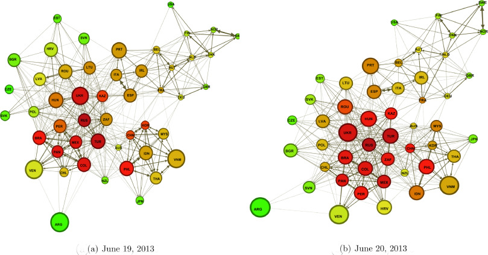

1. [Download: Download high-res image (1MB)](https://ars.els-cdn.com/content/image/1-s2.0-S0378426620300285-gr4_lrg.jpg)
2. [Download: Download full-size image](https://ars.els-cdn.com/content/image/1-s2.0-S0378426620300285-gr4.jpg)

Fig. 4. Return Connectedness of 49 Sovereigns Before and After Bernanke’s Speech, Scale = 120 See Appendix C for the list of countries included and Section 2.3 for graphical display method used.

Bernanke’s speech was expected to hit emerging markets. The escalation in the propagation volumes of these developing countries, as well as in Russia, Turkey, and Brazil, is not surprising. However, at the receiving end of the shocks, a different picture appears. The Czech Republic, Slovakia, and Australia, which have not seen significant increases in their ‘to connectedness’ measures, experienced the biggest increase in their ‘from connectedness’ measures. Moreover, emerging markets predominantly saw a larger increase in their ‘from connectedness’ measures than developed countries.<sup>27</sup>

#### 3.3.2. First Greek bailout

The first Greek bailout episode is important because it proves that the problems of the Greek economy were structural and would take years to solve. Furthermore, this episode has also proven that Greece’s fiscal problems could turn into a potentially contagious sovereign debt crisis in the EU periphery. In Fig. 5(a) and (b), eyeballing helps spot four main clusters on both May 3, and May 10, respectively. Latin American countries are on the upper side, East Asian countries are on the left, European countries on the right, and the remaining developing countries are in the middle.

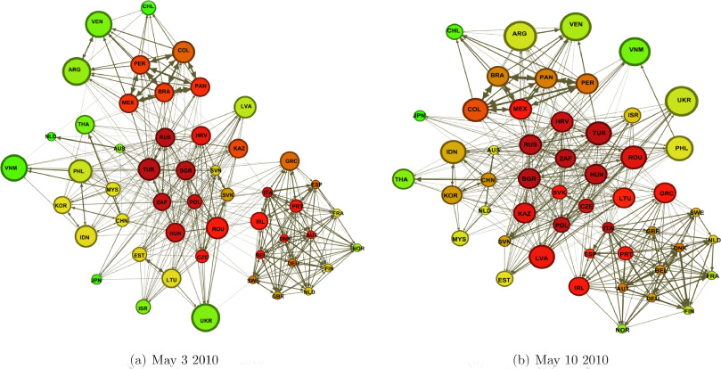

1. [Download: Download high-res image (1MB)](https://ars.els-cdn.com/content/image/1-s2.0-S0378426620300285-gr5_lrg.jpg)
2. [Download: Download full-size image](https://ars.els-cdn.com/content/image/1-s2.0-S0378426620300285-gr5.jpg)

Fig. 5. Return Connectedness of 50 SCDSs during the Greek Crisis, Scale = 150 See Appendix C for the list of countries included and Section 2.3 for the graphical display method used.

## 4. Implications for the determinants of sovereign credit risk

So far, the full sample and rolling sample window connectedness of SCDS returns have been analyzed. To draw in-depth conclusions, the implications of each daily network and dynamic pairwise connectedness can be separately analyzed. Instead, this section examines the general implications of the results.

**I-1:** **The connectedness of sovereign credit risk across the globe changes substantially over time**

Fig. 3 reveals how the total connectedness measures change over time. The shocks in other countries become more important in times of turmoil, when ‘from connectedness’ can be as high as 99.5% for some sovereigns; the auto-regressive structures of SCDS returns barely explain anything.

To illustrate this point, Fig. 6 presents two series: the dashed line corresponds to the ‘from connectedness’ of Slovakia, while the solid line corresponds to Lithuania. In 2009, the percent share of shocks in other countries in the determination of Slovakia’s SCDS returns was nearly three times the corresponding figure for Lithuania. After the Greek protests that followed the first [bailout](https://www.sciencedirect.com/topics/social-sciences/bailouts) package in May 2010, Lithuania’s ‘from connectedness’ surpassed that of Slovakia. The two series were indistinguishable for most of the crisis periods. For Slovakia, the importance of shocks in other countries has seen a big fall that followed the relief in the markets that began in 2013. After Bernanke’s speech, both sovereigns experienced a significant increase in their ‘from connectedness’. As of April 2014, Lithuania’s ‘from connectedness’ was twice as high as Slovakia’s.

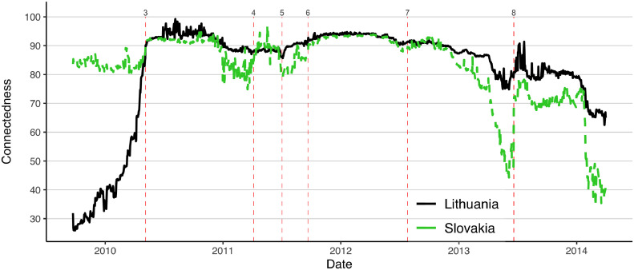

1. [Download: Download high-res image (371KB)](https://ars.els-cdn.com/content/image/1-s2.0-S0378426620300285-gr6_lrg.jpg)
2. [Download: Download full-size image](https://ars.els-cdn.com/content/image/1-s2.0-S0378426620300285-gr6.jpg)

Fig. 6. ‘From connectedness’ of Lithuania and Slovakia, 2009–2014. See the timetable of important events in Fig. 3.

At the start of 2009, Slovakia became a new member of the [Eurozone](https://www.sciencedirect.com/topics/social-sciences/eurozone). Before the advent of its membership, Slovakia’s adoption of the Euro was seen as highly advantageous because it involved a drop in the [exchange rate risk](https://www.sciencedirect.com/topics/economics-econometrics-and-finance/exchange-rate-risk) for borrowing, a more reliable [monetary policy](https://www.sciencedirect.com/topics/social-sciences/monetary-policy), and easier international commercial transactions. The Euro crisis, however, was a bitter surprise for the Slovak economy. Monetary stability became a disadvantage rather than an advantage, and borrowing became more difficult because of high risk in the Eurozone. However, Slovakia’s recovery after the crisis was successful: its strong banking sector probably allowed its sovereign credit risk to be less connected to shocks in other countries. Lithuania, in contrast, was one of the last sovereigns to be hit by the crisis, with high growth rates continuing until 2009. By 2009, Lithuania’s economy had shrunk by 15%, and after a devastating year, it managed to grow an average of 3.5%. After the crisis, plans to join the Eurozone were delayed. Lithuania had been scheduled to become a member of the Eurozone at the beginning of 2015, but many questioned the health of the Eurozone and wondered whether the loss of [monetary policy](https://www.sciencedirect.com/topics/earth-and-planetary-sciences/monetary-policy) independence necessitated by membership would render the country unable to deal with its economic problems. Therefore, as of March 2014, Lithuania was still highly influenced by outside shocks, most of which were created by European countries, before they officially adopted the Euro in 2015.

**I-2:** **The main drivers of global sovereign risk movements are emerging market countries**

Fig. 7 presents the average, minimum, and maximum values of the ‘to’ and ‘from connectedness’ measures for each of the 38 countries obtained from rolling windows during the 09/2009 to 04/2014 period.

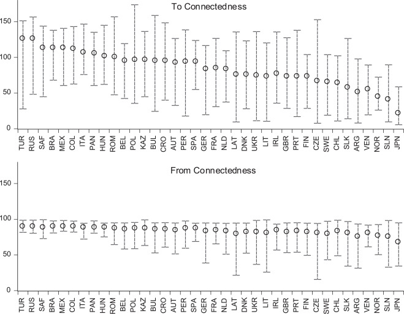

1. [Download: Download high-res image (699KB)](https://ars.els-cdn.com/content/image/1-s2.0-S0378426620300285-gr7_lrg.jpg)
2. [Download: Download full-size image](https://ars.els-cdn.com/content/image/1-s2.0-S0378426620300285-gr7.jpg)

Fig. 7. Maximum, Minimum and Average Values of ‘To’ and ‘From’ Connectedness in the Rolling Sample Window Analysis (09/2009 - 04/2014) Countries are listed according to the average ‘to connectedness’ measure in descending order. Country names and acronyms can be found in Table C.1.

Some troubled EU members (Italy, Belgium and Spain) and Central and Eastern European EU members (Hungary, Romania, Poland, Bulgaria) had relatively larger ‘to connectedness’ measures than other developed countries, but they were significantly behind the emerging markets. Turkey and Russia had the largest measures on average, closely followed by [South Africa](https://www.sciencedirect.com/topics/earth-and-planetary-sciences/republic-of-south-africa), Brazil, [Mexico](https://www.sciencedirect.com/topics/earth-and-planetary-sciences/mexico), and Colombia. Argentina and Venezuela, the most problematic countries of the last decade in terms of sovereign credit risk, were well behind.<sup>28</sup>

The possibility of contagion in the case of a default or debt restructuring is a significant source of fear among sovereigns. The cases of Russia in 1998, Argentina in 2005, and Greece, Portugal, and Ireland during the EU crisis were closely followed by global investors. Our findings show that the return connectedness of severely problematic SCDSs tends to increase during the build-up phase of a crisis. However, after the crisis peaks, the influence of the credit risk of severely problematic countries remains low–much lower, in fact, than their peak values. Thereafter, new rounds of shocks that originate from these countries can be transmitted not by themselves but by the other sovereigns most affected by the crisis.

**I-3:** **Global stock market indices, exchange rate movements and bond returns generate little connectedness to SCDS returns**

The financial and real sectors of countries are tightly connected through multiple channels. A slowing Chinese economy would affect the world oil price and, hence, the credit risks of Russia and Venezuela, whose revenues depend heavily on oil export revenues. An important question is whether sovereigns immediately respond to shocks in real and financial sectors of other sovereigns. Or does the response come after the effects of these shocks are reflected in the CDS spread of the source country? If the latter is true, then other variables would not add much explanatory power to a simple VAR analysis with SCDSs.

Data for primary stock indices, exchange rates, and five-year bond yields for all countries with data availability were collected to see if the return shocks to these asset classes can explain more than what is already explained by SCDS returns in the full sample. Fifty-eight stock market indices, 28 exchange rates, and 27 sovereign bonds are added to the original 38 SCDSs, making a total of 151 nodes in the network. To view and interpret an already overcrowded graph, we present in this section only the top 5% of the existing edges. The node sizes of primary indices, exchange rates, and bonds are all the same and equal to the average node size of SCDSs. The node color is used exclusively to distinguish asset classes.

In Fig. 8 (with only few exceptions), SCDSs (yellow nodes), primary stock indices (blue nodes), exchange rates (green nodes), and bonds (red nodes) form mutually exclusive clusters. The number of edges inside the clusters is considerably larger than the number of edges between the clusters. More importantly, the two-cluster structure of the SCDSs that appeared in Fig. 2 is preserved. We take this as suggestive evidence that the information contained in other assets prices are already reflected in SCDS spreads.

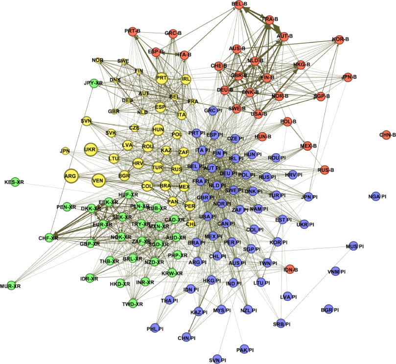

1. [Download: Download high-res image (2MB)](https://ars.els-cdn.com/content/image/1-s2.0-S0378426620300285-gr8_lrg.jpg)
2. [Download: Download full-size image](https://ars.els-cdn.com/content/image/1-s2.0-S0378426620300285-gr8.jpg)

Fig. 8. Return Connectedness Network of SCDSs, Stock Indices, Gov. Bonds, and Exchange Rates, 2010-14. The SCDS are represented with yellow nodes. The exchange rates are represented with green nodes and ‘-XR’ added to their country codes. The primary stock indices are represented with blue nodes and ‘-PI’ added to their country codes. The 5-yr government bonds are represented with red nodes and ‘-B’ added to their country codes. The thickest 5% of edges are presented. Node size denotes Fitch ratings for SCDS as before while it is equalized for other asset classes. (For interpretation of the references to colour in this figure legend, the reader is referred to the web version of this article.)

## 5. Pairwise connectedness and secondary regressions

This section analyzes the factors that can contribute to the connectedness of sovereign credit risk across countries. The focus is the relative importance of trade and investment flows from source to destination countries. First, a [panel data analysis](https://www.sciencedirect.com/topics/social-sciences/panel-data-analysis) with [fixed effects](https://www.sciencedirect.com/topics/social-sciences/fixed-effects-model) is run to estimate the full sample conditional correlations. Second, a series of quarterly cross-sectional regressions are estimated to see how the conditional correlations change over time. Both estimations are done with the 26 country samples between 2008 and 2019.

Panel data regressions over the full sample take the following form:(4)$θ˜ij,tg=β0+βXij,t+αj+γi+τt+uij,t$where $θ˜ij,tg$ is monthly average directional pairwise connectedness from country *j* to country *i* in percentage terms. *X*<sub>*ij,t*</sub> denotes a set of regressors that can include one-quarter lagged log trade flows (*i*’s exports to *j* and *i*’s imports from *j*), one-quarter lagged log financial capital flows (from *i* to *j* and from *j* to *i*), one-quarter lagged total log trade and capital flows, the log distance between the country *i* and *j*, and dummies for the [EU membership](https://www.sciencedirect.com/topics/economics-econometrics-and-finance/eu-membership) status of both countries.<sup>29</sup> *α<sub>i</sub>, γ<sub>j</sub>*, and *τ<sub>t</sub>* are the source, target and time fixed effects, respectively.

Table 1 presents the estimation results of Eq. 4 over the full sample. Pairwise connectedness is positively correlated with both trade and investment flows, and the quasi-elasticities of each are surprisingly similar, as seen in columns (1) and (2). Comparing their coefficients in columns (1) and (2) with (3) and (4) suggests that imports and exports are highly collinear, but the same cannot be said for [capital inflows](https://www.sciencedirect.com/topics/economics-econometrics-and-finance/capital-imports) and outflows. Distance seems to be a better predictor of connectedness than imports and exports, although the correlation is very high among all of them.<sup>30</sup> Furthermore, even after controlling for the source country fixed effects, pairwise connectedness from non-EU countries is significantly higher. Quarterly regressions will use the specification in column (6) since imports have time variation while the distance does not.

Cross-sectional regressions of the following form are run for each quarter:(5)$θ˜ijg=β0+βXij+αj+γi+uij$

Fig. 9 presents the resulting coefficient estimates along with the 95% confidence intervals.

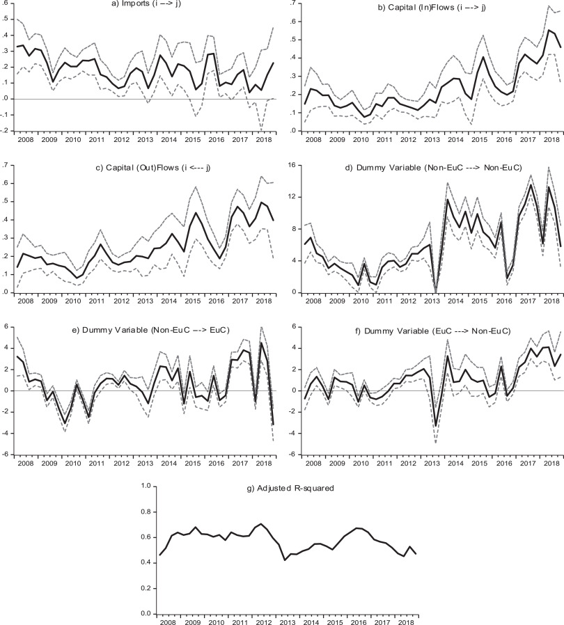

1. [Download: Download high-res image (1MB)](https://ars.els-cdn.com/content/image/1-s2.0-S0378426620300285-gr9_lrg.jpg)
2. [Download: Download full-size image](https://ars.els-cdn.com/content/image/1-s2.0-S0378426620300285-gr9.jpg)

Fig. 9. Sovereign Credit Risk Connectedness – Secondary Regressions (Quarterly; 2008/q1–2018/q4) Quarterly regressions use the specification in column (6) of Table 1. For more about each variable see the explanatory notes in Table 1.

Table 1. Sovereign Credit Risk Connectedness – Secondary Regressions (Full Sample; 02/2008–05/2019) Notes: *EuC* and *Non-EuC* are acronyms for EU-member and non EU-member countries, respectively. Capital flows correspond to the ‘Assets, Total Investment, BPM6, US dollars’ indicator from the IMF’s Coordinated Portfolio Investment Survey (CPIS), with had an annual frequency from 2009 to 2012 and a semiannual frequency from 2013 to 2017. Trade flows correspond to the ‘Value of merchandise exports and imports between countries’ indicator from the IMF’s Direction of Trade Statistics (DOTS), which has a monthly frequency. Distance is the ‘Weighted Distance’ indicator from GeoDist database by CEPII, which “... is the distance between two countries weighted by the distance by major cities weighted by their corresponding population shares in each respective country.” (Mayer and Zignago, 2011). Source and destination country as well as monthly dummies are included in all regressions. Standard errors are in parentheses. + *p* < 0.1; * *p* < 0.05; ** *p* < 0.01.

| Dependent Variable: $θ˜ij,tg$ – *Directional Pairwise Credit Risk Connectedness from j to i (i* ← *j)* Empty Cell | Dependent Variable: $θ˜ij,tg$ – *Directional Pairwise Credit Risk Connectedness from j to i (i* ← *j)* (1) | Dependent Variable: $θ˜ij,tg$ – *Directional Pairwise Credit Risk Connectedness from j to i (i* ← *j)* (2) | Dependent Variable: $θ˜ij,tg$ – *Directional Pairwise Credit Risk Connectedness from j to i (i* ← *j)* (3) | Dependent Variable: $θ˜ij,tg$ – *Directional Pairwise Credit Risk Connectedness from j to i (i* ← *j)* (4) | Dependent Variable: $θ˜ij,tg$ – *Directional Pairwise Credit Risk Connectedness from j to i (i* ← *j)* (5) | Dependent Variable: $θ˜ij,tg$ – *Directional Pairwise Credit Risk Connectedness from j to i (i* ← *j)* (6) |
| --- | --- | --- | --- | --- | --- | --- |
| **Exports** (*i* ← *j*) | 0.223<sup>⁎⁎</sup> | – | 0.108<sup>⁎⁎</sup> | – | – | – |
|  | (0.008) |  | (0.012) |  |  |  |
| **Imports** (*i* → *j*) | – | 0.224<sup>⁎⁎</sup> | 0.134<sup>⁎⁎</sup> | – | – | 0.182<sup>⁎⁎</sup> |
|  |  | (0.008) | (0.012) |  |  | (0.010) |
| **Capital (In)Flows** (*i* → *j*) | 0.246<sup>⁎⁎</sup> | – | 0.224<sup>⁎⁎</sup> | – | 0.137<sup>⁎⁎</sup> | 0.240<sup>⁎⁎</sup> |
|  | (0.006) |  | (0.008) |  | (0.007) | (0.008) |
| **Capital (Out)Flows** (*i* ← *j*) | – | 0.250<sup>⁎⁎</sup> | 0.229<sup>⁎⁎</sup> | – | 0.140<sup>⁎⁎</sup> | 0.225<sup>⁎⁎</sup> |
|  |  | (0.006) | (0.008) |  | (0.006) | (0.007) |
| **Total Trade** (*i*↔*j*) | – | – | – | 0.319<sup>⁎⁎</sup> | – | – |
|  |  |  |  | (0.012) |  |  |
| **Total Capital Flow** (*i*↔*j*) | – | – | – | 0.240<sup>⁎⁎</sup> | – | – |
|  |  |  |  | (0.008) |  |  |
| **Distance** (*i*↔*j*) | – | – | – | – | -1.456<sup>⁎⁎</sup> | – |
|  |  |  |  |  | (0.027) |  |
| **Dummy** (*Non-EuC* → *Non-EuC)* | 6.38<sup>⁎⁎</sup> | 6.31<sup>⁎⁎</sup> | 8.59<sup>⁎⁎</sup> | 3.15<sup>⁎⁎</sup> | 10.52<sup>⁎⁎</sup> | 7.79<sup>⁎⁎</sup> |
|  | (0.183) | (0.168) | (0.230) | (0.133) | (0.205) | (0.138) |
| **Dummy** (*Non-EuC* → *EuC)* | 2.04<sup>⁎⁎</sup> | 0.36<sup>⁎⁎</sup> | 2.43<sup>⁎⁎</sup> | $−0.27**$ | 4.29<sup>⁎⁎</sup> | 1.04<sup>⁎⁎</sup> |
|  | (0.158) | (0.083) | (0.163) | (0.081) | (0.149) | (0.083) |
| **Dummy** (*EuC* → *Non-EuC)* | $−0.310**$ | 1.114<sup>⁎⁎</sup> | 1.65<sup>⁎⁎</sup> | $−0.89**$ | 3.46<sup>⁎⁎</sup> | 2.05<sup>⁎⁎</sup> |
|  | (0.085) | (0.143) | (0.150) | (0.083) | (0.135) | (0.108) |
| **F statistic** | 527.5 | 482.8 | 423.6 | 457.6 | 562.1 | 453.5 |
| **Adjusted R-squared** | 0.402 | 0.396 | 0.426 | 0.380 | 0.471 | 0.431 |
| **Number of Observations** | 62,369 | 62,369 | 49,112 | 55,328 | 53,918 | 51,462 |

## 6. Conclusion

International investors and [financial institutions](https://www.sciencedirect.com/topics/economics-econometrics-and-finance/financial-institution) face new challenges in the age of globalized financial crises. For investors, risk diversification becomes quite difficult because in times of financial crises all markets appear to move in the same direction. For [international financial institutions](https://www.sciencedirect.com/topics/economics-econometrics-and-finance/international-economic-organization), containing a sovereign credit shock in the smallest possible set of countries with the correctly targeted use of limited financial resources is critical.

This paper provides important findings that should be helpful to both parties. It provides an estimate of the country credit risk network and demonstrates how the estimated network can be used to make better portfolio choices and use of regulatory funds. It also develops a framework that can be used to identify the countries that are the most and the least likely to be affected by a credit risk shock that originates from a particular country. More importantly, the paper shows that the originators of sovereign credit risk shocks are not necessarily the most important transmitters of these shocks. To predict how a [financial contagion](https://www.sciencedirect.com/topics/social-sciences/financial-contagion) evolves, investors and international financial institutions need to focus on SCDSs of the emerging markets that play a critical role in the transmission of shocks rather than on countries that are at the center of the crisis.

The methodology used in this paper will provide certain advantages to future research. The use of the elastic net breaks the curse of dimensionality and allows the estimation of large vector auto-regressions. As more detailed and accurate data become available, a larger number of countries can be included in the analysis.

## Appendix

The first section of the Appendix presents a brief discussion of the elastic net estimation. The second Appendix section presents the results of sensitivity analyses to check how robust the paper’s main results are to changes in various tuning parameters. The third section compares the system-wide connectedness measure with other commonly used financial stress indicators. The fourth section presents the bootstrap method used to obtain confidence bands for the connectedness measures. The last section provides the list of countries used in the analysis.

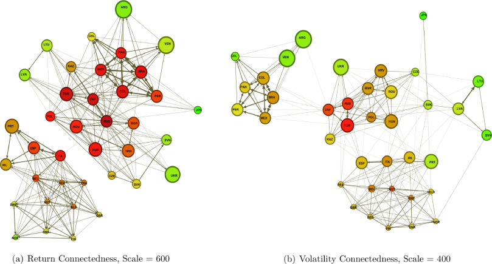

1. [Download: Download high-res image (1MB)](https://ars.els-cdn.com/content/image/1-s2.0-S0378426620300285-gr10_lrg.jpg)
2. [Download: Download full-size image](https://ars.els-cdn.com/content/image/1-s2.0-S0378426620300285-gr10.jpg)

Fig. A.1. Sovereign CDS Network, 2009–2014 using OLS (25% of the edges visible) See Appendix C for the list of countries included and Section 2.3 for the graphical display method used.

## Appendix A. Elastic net estimation

The elastic net estimator (Zou and Hastie (2005)) is a hybrid of shrinkage and selection methods. It chooses *β* vector that solves$β^Enet=argminβ(∑t=1T(yt−∑iβixit)2+λ∑i=1K(α|βi|+(1−α)βi2)).$Elastic net estimation combines the lasso *L*<sub>1</sub> regularization with the ridge *L*<sub>2</sub> regularization. It has two tuning parameters, *λ* and *α* ∈ [0, 1]. The estimator is equivalent to lasso when $α=1$ and to ridge when $α=0$. While lasso may select only one of the strongly correlated predictors and drop the others, elastic net makes sure that they are in or out of the model together. In the empirical analysis *α* is set to be equal to 0.5 without cross validation. Furthermore, 10-fold cross validation is used to choose the value of *λ*.<sup>33</sup>

In general, the elastic net produces biased estimates. However, there are reasons for overlooking the potential bias in the connectedness analysis.

First, elastic net applies shrinkage mainly on small coefficients forcing them to zero, therefore, underestimates smaller ties between sovereigns. However, even though elastic net allows the empirical researcher to estimate a sparse VAR, the resulting network is not sparse because entries in the variance decomposition matrix are determined not only by the estimated VAR coefficients, but also by the variance covariance matrix estimate.

Second, the higher coefficients are expected to be scaled down according to their sizes, therefore, relative importance of domestic and global factors does not necessarily change. In addition, the sovereigns with higher VAR coefficients are likely to be the ones with thicker edges in the network graph.

Third, the reader may inquire whether adaptive elastic net can be used on VAR estimation as it is used on simple linear regressions. Furman (2014) provides evidence that elastic net does not preclude efficient equation by equation estimation of VAR and the impulse response functions produced are valid.

Elastic Net estimation method is intuitively simple and appealing. It enables one to work with very high dimensional data, which would not be possible in the simple OLS framework. However, as any other method, it has its own drawbacks. The parameters are biased, since it does not minimize the sum of squared errors. The nature of the elastic net estimation method gives one reason to presume that the bias created by the elastic net estimation can be overlooked. However, it would be better to test this implicit assumption by comparing the results obtained from elastic net estimation to the results generated by simple OLS estimation.

In principle, the comparison can be done in small samples, however, it would be mostly inconclusive since OLS overfits when degrees of freedom is low. Indeed, the overfitting problem of OLS is the main reason behind the development and utilization of LASSO type methods. Therefore, results of the OLS estimation is likely to differ from the results of the elastic net estimation when degrees of freedom is low. In addition, the rolling window analyses for particular events cannot be replicated with OLS since degrees of freedom is negative for most of the windows. The network graphs obtained with the elastic net estimation are replicated with OLS estimation for the full sample, where there is considerable degrees of freedom. The OLS estimation based network graphs are presented in Fig. A.1. Even though the graphs are not identical to the ones in the main text (Fig. 2), all the major results discussed in the paper still hold. Both methods produce the same clustering structure, the same coloring scheme across sovereigns, and the same relation between the return and volatility connectedness plots in the full sample.

Another tricky side of the elastic net estimation method is determination of the shrinkage coefficient *λ*. The classic method is cross-validation. However, in time series data, the errors are correlated and *λ* determined by cross validation may not be the correct one. In the dynamic analysis, *λ* parameter is cross validated for each window separately. To measure the dependence of the results on the *λ* parameter, the dynamic analysis is conducted using only the smallest and largest *λ* values without doing any cross validation.

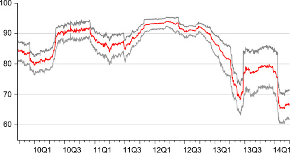

1. [Download: Download high-res image (313KB)](https://ars.els-cdn.com/content/image/1-s2.0-S0378426620300285-gr11_lrg.jpg)
2. [Download: Download full-size image](https://ars.els-cdn.com/content/image/1-s2.0-S0378426620300285-gr11.jpg)

Fig. B.1. Connectedness of SCDS Returns with Bootstrapped 95% Confidence Interval.

## Appendix B. Bootstrap Method

Here we briefly summarize the bootstrap procedure applied. The estimation follows the sieve bootstrap procedure as introduced in Freedman (1984). Let *N* be the number of variables, *T* the length of the time series variable and *L* the number of lags. The following procedure is used to generate bootstrap samples:

(i) Sample a random number *n* from 1 to $T−L$.

(ii) Use the observations from *n* to $n+L$ as the initial points.

(iii) Sample a random number *t* from 1 to *T*. Generate observation $n+L+1$ by multiplying the *L* initial observations with the estimated coefficients and adding the residuals from the observation *t* where both coefficients and residuals are estimated with the original dataset.

(iv) Repeat (iii) for the next observation until a new bootstrap sample of length *T* is generated.

(v) Do the estimation again with the boostrap sample to get bootstrap coefficients and compute bootstrap connectedness measures.

(vi) Repeat (i) to (v) 1000 times.

## Appendix C. Country acronyms

Table C.1. Country Acronyms The countries that are also included in the 26-country analyses are indicated with stars. The countries that are not in the 38-country sample, but are in the analyses for specific dates are indicated with italic font.

| Argentina (ARG) | Hungary (HUN) | Portugal* (PRT) |
| --- | --- | --- |
| Austria* (AUT) | Ireland* (IRL) | Romania (ROM) |
| Belgium* (BEL) | Italy* (ITA) | Russia* (RUS) |
| Brazil (BRA) | Japan* (JPN) | Slovakia* (SLK) |
| Bulgaria* (BUL) | Kazakhstan* (KAZ) | Slovenia* (SLN) |
| Chile* (CHL) | Latvia* (LAT) | South Africa (SAF) |
| Colombia* (COL) | Lithuania (LIT) | Spain* (SPA) |
| Croatia* (CRO) | Mexico* (MEX) | Sweden (SWE) |
| Czech Republic* (CZE) | Netherlands* (NLD) | Turkey* (TUR) |
| Denmark (DNK) | Norway (NOR) | Ukraine (UKR) |
| Finland (FIN) | Panama* (PAN) | United Kingdom* (GBR) |
| France* (FRA) | Peru* (PER) | Venezuela (VEN) |
| Germany* (GER) | Poland* (POL) | *Australia (AUS)* |
| *China (CHN)* | *Estonia (EST)* | *Greece (GRC)* |
| *Indonesia (IDN)* | *Israel (ISR)* | *South Korea (KOR)* |
| *Malaysia (MYS)* | *New Zealand (NLD)* | *Philippines (PHL)* |
| *Thailand (THA)* | *United States (USA)* | *Vietnam (VNM)* |

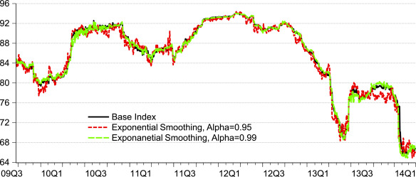

1. [Download: Download high-res image (522KB)](https://ars.els-cdn.com/content/image/1-s2.0-S0378426620300285-gr12_lrg.jpg)
2. [Download: Download full-size image](https://ars.els-cdn.com/content/image/1-s2.0-S0378426620300285-gr12.jpg)

Fig. D.1. Sensitivity of Connectedness Index to Exponential smoothing.

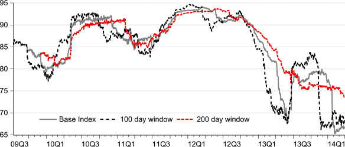

1. [Download: Download high-res image (432KB)](https://ars.els-cdn.com/content/image/1-s2.0-S0378426620300285-gr13_lrg.jpg)
2. [Download: Download full-size image](https://ars.els-cdn.com/content/image/1-s2.0-S0378426620300285-gr13.jpg)

Fig. D.2. Sensitivity of Connectedness Index to Rolling Window Size.

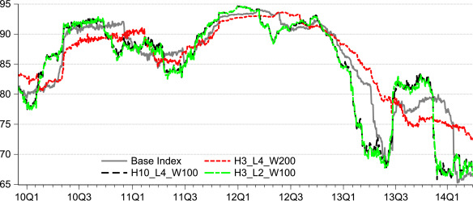

1. [Download: Download high-res image (550KB)](https://ars.els-cdn.com/content/image/1-s2.0-S0378426620300285-gr14_lrg.jpg)
2. [Download: Download full-size image](https://ars.els-cdn.com/content/image/1-s2.0-S0378426620300285-gr14.jpg)

Fig. D.3. Sensitivity of the Connectedness Index to Three Tuning Parameters.

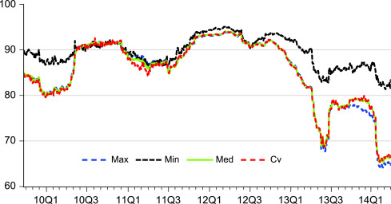

1. [Download: Download high-res image (330KB)](https://ars.els-cdn.com/content/image/1-s2.0-S0378426620300285-gr15_lrg.jpg)
2. [Download: Download full-size image](https://ars.els-cdn.com/content/image/1-s2.0-S0378426620300285-gr15.jpg)

Fig. D.4. Sensitivity of the Connectedness Index to Elastic Net Parameter *λ*.

## Appendix D. Sensitivity of the results to tuning parameters

The connectedness measures used in the analysis depend on three choice variables, namely, the order of the VAR model (that is, the number of lags of endogenous variable included), rolling window size and the forecast horizon. It’s impossible to test all of the results for different choices of these variables. Thus, the sensitivity analysis is limited to the dynamics of the system-wide connectedness index and the full sample network graphs. The usual choices for these variables are 3 for the order of the VAR model, 150-days for the size of the rolling window and 10-days for the forecast horizon. Sensitivity analysis results for 2 and 4 lags, 100-day and 200-day rolling windows and 3-day forecast horizon are presented below.<sup>34</sup> As the volatility connectedness results are quite similar to the ones obtained for return connectedness, in this appendix the focus will be only on return connectedness.

Before focusing on the sensitivitiy of the results to the tuning parameters, Fig. D.1 reports the dynamic connectedness index with exponential smoothing, where more recent observations have larger weights in estimation. As the weight given to the more recent observations increases, the index becomes more ragged. However, the main results obtained with equal weights to all observations included in the rolling window do not change.

As the plots of the system-wide connectedness index for different forecast horizons are virtually indistinguishable, they are not presented in a seperate Figure. Instead, the sensitivity analysis focused on simultaneous changes in tuning parameters, that is, the forecast horizon, the window size as well as the order of the VAR model. The results of this exercise are presented in Fig. D.3. The dynamic system-wide connectedness index plot can vary substantially when all three tuning parameters are changed simultaneously.

Fig. D.3 presents results for a sample of changes in tuning parameters. While the forecast horizon is set to 3 or 10 days, the window size is set to 100 or 200 days and the order of the VAR model is set to 2 or 4 days. The outcome of this exercise points to one conclusion: The major changes in the dynamic connectedness graphs are still dictated by the change in the rolling window size. No specific impact of the interaction of multiple parameter changes are observed in the behavior of the dynamic connectednes index.

Another tricky side of the elastic net estimation method is determining the shrinkage coefficient *λ*. The classic and widely-used method is cross-validation. However, in time-series data, the errors are correlated and *λ* determined by cross-validation may not be the correct one. In the rolling-window analysis, *λ* parameter is cross-validated for each window separately. To measure the dependence of the results on the *λ* parameter, we take an extreme approach and conduct the rolling-window analysis again using only the smallest ($Min=0.000088$), the largest ($Max=0.04957$) and the median ($Med=0.00932$) values of *λ* for any country in any rolling window without any cross-validation. This way, we aim to get some ad-hoc upper and lower bounds on the index, however wide they might be. The results for the system-wide index are presented in Fig. D.4. The dashed black line, which corresponds to the minimum value, shows a much smaller variation, compared to the cross-validated (*Cv*), the largest and the median values. This is understandable, as the minimum value is surprisingly close to 0 and the elastic net estimator requires a nonzero weight to be consistent. Regardless, although the magnitude of the swings in the system-wide index seems to depend on the value of *λ*, the swings happen at similar times.

## Appendix E. Connectedness Index & financial stress indicators

In this section, Fig. E.1 plots the system-wide connectedness index (computed with SCDS data from 38 countries between September 2009 and March 2014) along with other commonly used financial stress indicators. Table E.1 presents the correlation between the system-wide connectedness index and the commonly-used financial stress indicators.

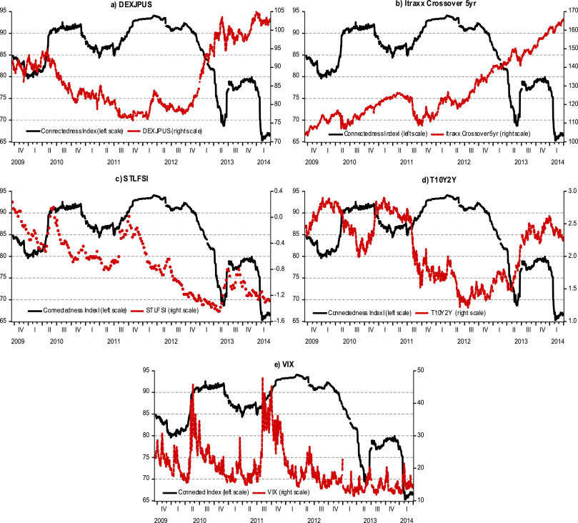

1. [Download: Download high-res image (2MB)](https://ars.els-cdn.com/content/image/1-s2.0-S0378426620300285-gr16_lrg.jpg)
2. [Download: Download full-size image](https://ars.els-cdn.com/content/image/1-s2.0-S0378426620300285-gr16.jpg)

Fig. E.1. System-wide connectedness index and commonly used financial stress indicators see Table E.1 about the five indicators plotted along with the system-wide connectedness index.

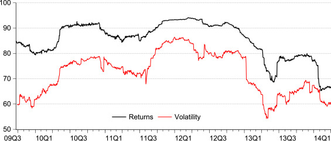

1. [Download: Download high-res image (350KB)](https://ars.els-cdn.com/content/image/1-s2.0-S0378426620300285-gr17_lrg.jpg)
2. [Download: Download full-size image](https://ars.els-cdn.com/content/image/1-s2.0-S0378426620300285-gr17.jpg)

Fig. F.1. System-wide Connectedness of SCDS Returns and [Return Volatilities](https://www.sciencedirect.com/topics/economics-econometrics-and-finance/returns-volatility), 38 Country Sample.

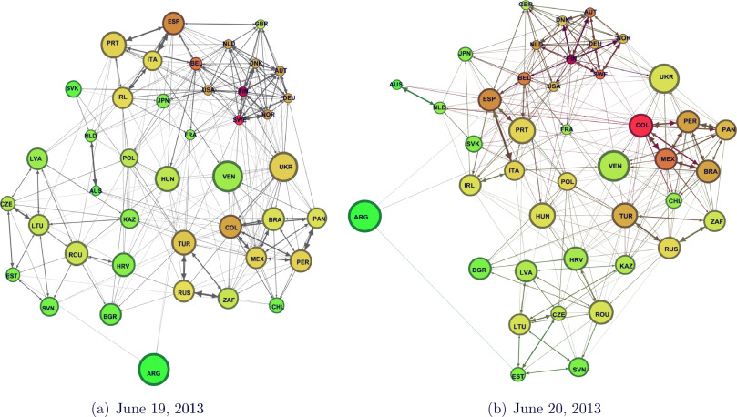

1. [Download: Download high-res image (1MB)](https://ars.els-cdn.com/content/image/1-s2.0-S0378426620300285-gr18_lrg.jpg)
2. [Download: Download full-size image](https://ars.els-cdn.com/content/image/1-s2.0-S0378426620300285-gr18.jpg)

Fig. F.2. Volatility Connectedness of 42 Sovereigns after Bernanke’s Speech, Scale = 120 See Appendix C for the list of countries included and Section 2.3 for graphical display method used.

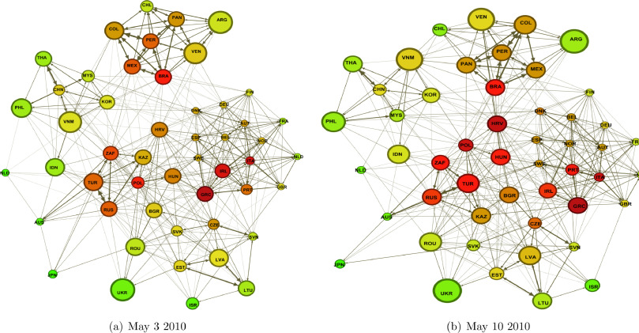

1. [Download: Download high-res image (1MB)](https://ars.els-cdn.com/content/image/1-s2.0-S0378426620300285-gr19_lrg.jpg)
2. [Download: Download full-size image](https://ars.els-cdn.com/content/image/1-s2.0-S0378426620300285-gr19.jpg)

Fig. F.3. Volatility Connectedness of 50 SCDSs during the Greek Crisis, Scale = 150 See Appendix C for the list of countries included and Section 2.3 for the graphical display method used.

Table E.1. The correlation of the system-wide connectedness index (DY) with commonly used financial stress indicators and their one-week leads and lags. CBOE Volatility Index (VIX), [St. Louis](https://www.sciencedirect.com/topics/earth-and-planetary-sciences/st-louis) Fed Financial Stress Index (STLFSI), 10-Year Treasury Constant Maturity Yield Minus 2-Year Treasury Constant Maturity Yield (T10Y2Y), and Japan/U.S. Foreign Exchange Rate (DEXJPUS) are from the FRED database of Federal Reserve Bank of St. Louis. iTraxx Crossover Index (iTraxx Crossover 5yr) is from the Markit database. All indices are in daily frequency, except for STLFSI, which is weekly.

| Empty Cell | VIX | STLFSI | T10Y2Y | iTraxx Crossover 5yr | DEXJPUS |
| --- | --- | --- | --- | --- | --- |
| Correlation (*DY<sub>t</sub>, X<sub>t</sub>*) | 0.41 | 0.43 | −0.32 | −0.69 | −0.86 |
| Correlation (*DY<sub>t</sub>*, $Xt−7$) | 0.42 | 0.42 | −0.38 | −0.66 | −0.84 |
| Correlation (*DY<sub>t</sub>*, $Xt+7$) | 0.35 | 0.37 | −0.42 | −0.64 | −0.84 |

## Appendix F. Volatility connectedness

### F1. Dynamic evolution of the determinants of SCDS volatilities

The system-wide connectedness of SCDS spread volatilities -that is, what percentage of the forecast error for volatilities can be attributed to shocks originating from other countries, on average- is presented with the red line in Fig. F.1. The system-wide connectedness index of volatilities is always above 50%, i.e., more than half of the changes in SCDS volatilities in the sample can be attributed to other countries. Moreover, the volatility connectedness index is very highly correlated with the return connectedness index. Although the correlation is high, the SCDS volatilities are affected less from other countries compared to returns. This might be related to the full sample result where the modularity of the volatility network is significantly higher than the modularity of the return network. Acemoglu et al. (2015) presents a model where within-cluster contagion in networks is more likely where there are multiple clusters in which the members are strongly connected with each other and relatively less connected with the members of other clusters. In this scenario, volatility shocks would be mostly transmitted within the same cluster, and much less across different clusters. As the return connectedness graph has lower modularity, the return shocks would be transmitted within the same cluster as well as across the other clusters.

There are three large and sudden changes in the volatility index. The first is at the beginning of May, where the connectedness index has increased around 5% over a two weeks period. This period coincides with the agreement over the bailout for Greece. The second one is a two-day increase on June 4, and June 5, 2012, just after a large stock market decline all over the world following news on slowing Chinese manufacturing growth and discouraging employment data in the US. The third increase is right after Bernanke’s speech on June 20, 2013.

The steady decrease after Draghi’s “Whatever It Takes” speech is even more pronounced for volatilities with a striking decrease starting on January 4, 2013 and continuing with the second week of January 2013. In this period, the spread volatilities of developing countries decreased although the volatilities of PIIS countries increased. On January 10, Draghi also announced that there is a ‘positive contagion’ in the economy and the problems are slowly being repaired in the economy with the stabilization of the bond markets.

### F2. Bernanke’s June 19, 2013 press conference and the taper tantrum

Fig. F.2(a) and (b) show a similar compression to return connectedness graphs after the Bernanke speech with the exception of Argentina. After the speech, the PIIS countries approach to the center of the graph while Eastern European countries approach to the Russia-Turkey-South Africa triangle. Latin American countries have the biggest increase in their ‘to connectedness’ (ranging from 11% to 27%) with the exception of Venezuela and Argentina. They are followed by the CESEE countries; particularly Poland, Austria, Slovakia, and Hungary. Turkey and Kazakhistan also see increases close to 10% in their ‘to connectedness’. South Africa, which has seen the biggest increase in its ‘to connectedness’ in returns has seen a modest increase in its volatility transmittance with 1.5%. On the receiving end, we see an overall increase but Eastern European countries stand out with the largest increases in ‘from connectedness’ measures.

## References

1. Acemoglu, Ozdaglar, Tahbaz-Salehi, 2015

   D. Acemoglu, A. Ozdaglar, A. Tahbaz-Salehi

   Systemic risk and stability in financial networks

   Am. Econ. Rev., 105 (2) (2015), pp. 564-608, 10.1257/aer.20130456

   [View in Scopus](https://www.scopus.com/inward/record.url?eid=2-s2.0-84922238979&partnerID=10&rel=R3.0.0)[Google Scholar](https://scholar.google.com/scholar_lookup?title=Systemic%20risk%20and%20stability%20in%20financial%20networks&publication_year=2015&author=D.%20Acemoglu&author=A.%20Ozdaglar&author=A.%20Tahbaz-Salehi)
2. Acharya, Yorulmazer, 2008

   V.V. Acharya, T. Yorulmazer

   Information contagion and bank herding

   J. Money Credit Bank., 40 (1) (2008), pp. 215-231

   [Crossref](https://doi.org/10.1111/j.1538-4616.2008.00110.x)[View in Scopus](https://www.scopus.com/inward/record.url?eid=2-s2.0-38749139183&partnerID=10&rel=R3.0.0)[Google Scholar](https://scholar.google.com/scholar_lookup?title=Information%20contagion%20and%20bank%20herding&publication_year=2008&author=V.V.%20Acharya&author=T.%20Yorulmazer)
3. Aizenman, Hutchison, Jinjarak, 2013

   J. Aizenman, M. Hutchison, Y. Jinjarak

   What is the risk of European sovereign debt defaults? Fiscal space, CDS spreads and market pricing of risk

   J. Int. Money Finance, 34 (0) (2013), pp. 37-59

   [View PDF](https://www.sciencedirect.com/science/article/pii/S0261560612001908/pdfft?md5=c1f047573aabf4ea3376ba1acfdccedd&pid=1-s2.0-S0261560612001908-main.pdf)[View article](https://www.sciencedirect.com/science/article/pii/S0261560612001908)[View in Scopus](https://www.scopus.com/inward/record.url?eid=2-s2.0-84875252060&partnerID=10&rel=R3.0.0)Google Scholar
4. Allen, Babus, Carletti, 2012

   F. Allen, A. Babus, E. Carletti

   Asset commonality, debt maturity and systemic risk

   J. Financ. Econ., 104 (3) (2012), pp. 519-534

   [View PDF](https://www.sciencedirect.com/science/article/pii/S0304405X11001644/pdfft?md5=c59bb9eed70a662a31c2d84fe576a90f&pid=1-s2.0-S0304405X11001644-main.pdf)[View article](https://www.sciencedirect.com/science/article/pii/S0304405X11001644)[View in Scopus](https://www.scopus.com/inward/record.url?eid=2-s2.0-84860446030&partnerID=10&rel=R3.0.0)[Google Scholar](https://scholar.google.com/scholar_lookup?title=Asset%20commonality%2C%20debt%20maturity%20and%20systemic%20risk&publication_year=2012&author=F.%20Allen&author=A.%20Babus&author=E.%20Carletti)
5. Allen, Gale, 2000

   F. Allen, D. Gale

   Financial contagion

   J. Polit. Econ., 108 (2000), pp. 1-33

   [View in Scopus](https://www.scopus.com/inward/record.url?eid=2-s2.0-0034079058&partnerID=10&rel=R3.0.0)[Google Scholar](https://scholar.google.com/scholar_lookup?title=Financial%20contagion&publication_year=2000&author=F.%20Allen&author=D.%20Gale)
6. Alter, Beyer, 2014

   A. Alter, A. Beyer

   The dynamics of spillover effects during the European sovereign debt turmoil

   J. Bank. Finance, 42 (0) (2014), pp. 134-153

   [View PDF](https://www.sciencedirect.com/science/article/pii/S0378426614000442/pdfft?md5=f319ec8fdb9b398c903db615a21ce265&pid=1-s2.0-S0378426614000442-main.pdf)[View article](https://www.sciencedirect.com/science/article/pii/S0378426614000442)[View in Scopus](https://www.scopus.com/inward/record.url?eid=2-s2.0-84894260354&partnerID=10&rel=R3.0.0)[Google Scholar](https://scholar.google.com/scholar_lookup?title=The%20dynamics%20of%20spillover%20effects%20during%20the%20European%20sovereign%20debt%20turmoil&publication_year=2014&author=A.%20Alter&author=A.%20Beyer)
7. Ang, Longstaff, 2013

   A. Ang, F. Longstaff

   Systemic sovereign credit risk: lessons from the U.S. and Europe

   J. Monet. Econ., 60 (2013), pp. 493-510

   [View PDF](https://www.sciencedirect.com/science/article/pii/S0304393213000585/pdfft?md5=386d4260deb89414f9c6827da70b6122&pid=1-s2.0-S0304393213000585-main.pdf)[View article](https://www.sciencedirect.com/science/article/pii/S0304393213000585)[View in Scopus](https://www.scopus.com/inward/record.url?eid=2-s2.0-84881111988&partnerID=10&rel=R3.0.0)[Google Scholar](https://scholar.google.com/scholar_lookup?title=Systemic%20sovereign%20credit%20risk%3A%20lessons%20from%20the%20U.S.%20and%20Europe&publication_year=2013&author=A.%20Ang&author=F.%20Longstaff)
8. Augustin, Tédongap, 2016

   P. Augustin, R. Tédongap

   Real economic shocks and sovereign credit risk

   J. Financ. Quant. Anal., 51 (2) (2016), pp. 541-587

   [View in Scopus](https://www.scopus.com/inward/record.url?eid=2-s2.0-84979255730&partnerID=10&rel=R3.0.0)[Google Scholar](https://scholar.google.com/scholar_lookup?title=Real%20economic%20shocks%20and%20sovereign%20credit%20risk&publication_year=2016&author=P.%20Augustin&author=R.%20T%C3%A9dongap)
9. Beirne, Fratzscher, 2013

   J. Beirne, M. Fratzscher

   The pricing of sovereign risk and contagion during the European sovereign debt crisis

   J. Int. Money. Finance, 34 (0) (2013), pp. 60-82, 10.1016/j.jimonfin.2012.11.004

   [View PDF](https://www.sciencedirect.com/science/article/pii/S0261560612001830/pdfft?md5=5f0edbd88bab9eed1fdcb8edd9a489b6&pid=1-s2.0-S0261560612001830-main.pdf)[View article](https://www.sciencedirect.com/science/article/pii/S0261560612001830)[View in Scopus](https://www.scopus.com/inward/record.url?eid=2-s2.0-84875407009&partnerID=10&rel=R3.0.0)Google Scholar
10. Bekaert, Harvey, Lundblad, Siegel, 2014

    G. Bekaert, C. Harvey, C. Lundblad, S. Siegel

    Political risk spreads

    J. Int. Bus. Stud., 45 (4) (2014), pp. 471-493, 10.1057/jibs.2014.4

    [View in Scopus](https://www.scopus.com/inward/record.url?eid=2-s2.0-84901054764&partnerID=10&rel=R3.0.0)[Google Scholar](https://scholar.google.com/scholar_lookup?title=Political%20risk%20spreads&publication_year=2014&author=G.%20Bekaert&author=C.%20Harvey&author=C.%20Lundblad&author=S.%20Siegel)
11. Blodel, Guillaume, Lambiotte, Lefebvre, 2008

    V.D. Blodel, J. Guillaume, R. Lambiotte, E. Lefebvre

    Fast unfolding of communities in large networks

    J. Stat. Mech., 2008 (2008), p. P10008

    Google Scholar
12. Cho, Choi, 2015

    D. Cho, K. Choi

    Time-varying co-movements and contagion effects in Asian sovereign CDS markets

    J. East Asian Econ. Integr., 19 (4) (2015), pp. 357-379

    [Crossref](https://doi.org/10.11644/kiep.jeai.2015.19.4.301)[Google Scholar](https://scholar.google.com/scholar_lookup?title=Time-varying%20co-movements%20and%20contagion%20effects%20in%20Asian%20sovereign%20CDS%20markets&publication_year=2015&author=D.%20Cho&author=K.%20Choi)
13. Collet, Ielpo, 2018

    J. Collet, F. Ielpo

    Sector spillovers in credit markets

    J. Bank. Finance, 94 (2018), pp. 267-278, 10.1016/j.jbankfin.2018.07.011

    [View PDF](https://www.sciencedirect.com/science/article/pii/S0378426618301584/pdfft?md5=56d4b75e7d47d86ce35dc631b3f18316&pid=1-s2.0-S0378426618301584-main.pdf)[View article](https://www.sciencedirect.com/science/article/pii/S0378426618301584)[View in Scopus](https://www.scopus.com/inward/record.url?eid=2-s2.0-85052233121&partnerID=10&rel=R3.0.0)[Google Scholar](https://scholar.google.com/scholar_lookup?title=Sector%20spillovers%20in%20credit%20markets&publication_year=2018&author=J.%20Collet&author=F.%20Ielpo)
14. Demirer, Diebold, Liu, Yilmaz, 2018

    M. Demirer, F. Diebold, L. Liu, K. Yilmaz

    Estimating global bank network connectedness

    J. Appl. Econom., 33 (1) (2018), pp. 1-15

    [Crossref](https://doi.org/10.1002/jae.2585)[View in Scopus](https://www.scopus.com/inward/record.url?eid=2-s2.0-85026433436&partnerID=10&rel=R3.0.0)[Google Scholar](https://scholar.google.com/scholar_lookup?title=Estimating%20global%20bank%20network%20connectedness&publication_year=2018&author=M.%20Demirer&author=F.%20Diebold&author=L.%20Liu&author=K.%20Yilmaz)
15. Diebold, Yilmaz, 2009

    F. Diebold, K. Yilmaz

    Measuring financial asset return and volatility spillovers, with application to global equity markets

    Econ. J., 119 (2009), pp. 158-171

    [Crossref](https://doi.org/10.1111/j.1468-0297.2008.02208.x)[View in Scopus](https://www.scopus.com/inward/record.url?eid=2-s2.0-57749109009&partnerID=10&rel=R3.0.0)Google Scholar
16. Diebold, Yilmaz, 2012

    F. Diebold, K. Yilmaz

    Better to give than to receive: predictive measurement of volatility spillovers

    Int. J. Forecast, 28 (2012), pp. 57-66

    [View PDF](https://www.sciencedirect.com/science/article/pii/S016920701100032X/pdfft?md5=9d977ac2746422b71ee2954691a6b737&pid=1-s2.0-S016920701100032X-main.pdf)[View article](https://www.sciencedirect.com/science/article/pii/S016920701100032X)[View in Scopus](https://www.scopus.com/inward/record.url?eid=2-s2.0-84155181176&partnerID=10&rel=R3.0.0)Google Scholar
17. Diebold, Yilmaz, 2014

    F. Diebold, K. Yilmaz

    On the network topology of variance decompositions: measuring the connectedness of financial firms

    J. Econom., 182 (2014), pp. 119-134

    [View PDF](https://www.sciencedirect.com/science/article/pii/S0304407614000712/pdfft?md5=10774abcacd3856e076acc4994a4da3c&pid=1-s2.0-S0304407614000712-main.pdf)[View article](https://www.sciencedirect.com/science/article/pii/S0304407614000712)[View in Scopus](https://www.scopus.com/inward/record.url?eid=2-s2.0-84901841234&partnerID=10&rel=R3.0.0)Google Scholar
18. Freedman, 1984

    D. Freedman

    On bootstrapping two-stage least-squares estimates in stationary linear models

    Ann. Stat., 12 (3) (1984), pp. 827-842

    [Google Scholar](https://scholar.google.com/scholar_lookup?title=On%20bootstrapping%20two-stage%20least-squares%20estimates%20in%20stationary%20linear%20models&publication_year=1984&author=D.%20Freedman)
19. Furman

    Furman, Y., 2014. Var estimation with the adaptive elastic net. Available at SSRN: https://ssrn.com/abstract=2456510.

    [Google Scholar](https://scholar.google.com/scholar?q=Furman%2C%20Y.%2C%202014.%20Var%20estimation%20with%20the%20adaptive%20elastic%20net.%20Available%20at%20SSRN%3A%20https%3A%2F%2Fssrn.com%2Fabstract%3D2456510.)
20. Garman, Klass, 1980

    M.B. Garman, M.J. Klass

    On the estimation of security price volatilities from historical data

    J. Bus., 53 (1) (1980), pp. 67-78

    [Google Scholar](https://scholar.google.com/scholar_lookup?title=On%20the%20estimation%20of%20security%20price%20volatilities%20from%20historical%20data&publication_year=1980&author=M.B.%20Garman&author=M.J.%20Klass)
21. Gyntelberg, Hördahl, Ters, Urban

    Gyntelberg, J., Hördahl, P., Ters, K., Urban, J., 2013. Intraday dynamics of sovereign CDS and bonds. BIS Working Paper, No 423.

    Google Scholar
22. Heinz, Sun

    Heinz, F. F., Sun, Y., 2014. Sovereign CDS spreads in europe: the role of global risk aversion, economic fundamentals, liquidity, and spillovers. IMF Working Paper n. 14/17.

    Google Scholar
23. Hilscher, Nosbusch, 2010

    J. Hilscher, Y. Nosbusch

    Determinants of sovereign risk: macroeconomic fundamentals and the pricing of sovereign debt

    Rev. Financ, 14 (2010), pp. 235-262

    [Crossref](https://doi.org/10.1093/rof/rfq005)[View in Scopus](https://www.scopus.com/inward/record.url?eid=2-s2.0-77951249446&partnerID=10&rel=R3.0.0)Google Scholar
24. Jacomy, Heymann, Venturini, Bastian, 2014

    M. Jacomy, S. Heymann, T. Venturini, M. Bastian

    ForceAtlas2: a continuous graph layout algorithm for handy network visualization designed for the Gephi software

    PLoS ONE, 9 (6) (2014), p. e98679

    [Crossref](https://doi.org/10.1371/journal.pone.0098679)[View in Scopus](https://www.scopus.com/inward/record.url?eid=2-s2.0-84902603261&partnerID=10&rel=R3.0.0)Google Scholar
25. Jeanneret, 2018

    A. Jeanneret

    Sovereign credit spreads under good/bad governance

    J. Bank. Finance, 93 (2018), pp. 230-246

    [View PDF](https://www.sciencedirect.com/science/article/pii/S0378426618300736/pdfft?md5=7b91db406ebff3fe1c3608bce88e3b58&pid=1-s2.0-S0378426618300736-main.pdf)[View article](https://www.sciencedirect.com/science/article/pii/S0378426618300736)[View in Scopus](https://www.scopus.com/inward/record.url?eid=2-s2.0-85049423937&partnerID=10&rel=R3.0.0)[Google Scholar](https://scholar.google.com/scholar_lookup?title=Sovereign%20credit%20spreads%20under%20goodbad%20governance&publication_year=2018&author=A.%20Jeanneret)
26. Koop, Pesaran, Potter, 1996

    G. Koop, M. Pesaran, S. Potter

    Impulse response analysis in nonlinear multivariate models

    J. Econom., 74 (1) (1996), pp. 119-147

    [View PDF](https://www.sciencedirect.com/science/article/pii/0304407695017534/pdf?md5=f4f38c2302eb8f889f7bf036378070e0&pid=1-s2.0-0304407695017534-main.pdf)[View article](https://www.sciencedirect.com/science/article/pii/0304407695017534)[View in Scopus](https://www.scopus.com/inward/record.url?eid=2-s2.0-0001353625&partnerID=10&rel=R3.0.0)[Google Scholar](https://scholar.google.com/scholar_lookup?title=Impulse%20response%20analysis%20in%20nonlinear%20multivariate%20models&publication_year=1996&author=G.%20Koop&author=M.%20Pesaran&author=S.%20Potter)
27. Longstaff, Pan, Pedersen, Singleton, 2011

    F. Longstaff, J. Pan, L. Pedersen, K. Singleton

    How sovereign is sovereign credit risk?

    Am. Econ. J., 3 (2011), pp. 75-103

    [Crossref](https://doi.org/10.1257/mac.3.2.75)[View in Scopus](https://www.scopus.com/inward/record.url?eid=2-s2.0-79958088403&partnerID=10&rel=R3.0.0)[Google Scholar](https://scholar.google.com/scholar_lookup?title=How%20sovereign%20is%20sovereign%20credit%20risk&publication_year=2011&author=F.%20Longstaff&author=J.%20Pan&author=L.%20Pedersen&author=K.%20Singleton)
28. Mayer, Zignago, 2011

    T. Mayer, S. Zignago

    Notes on CEPII’s distances measures: the GeoDist database

    CEPII Working Paper 2011-25 (2011)

    [Google Scholar](https://scholar.google.com/scholar_lookup?title=Notes%20on%20CEPIIs%20distances%20measures%3A%20the%20GeoDist%20database&publication_year=2011&author=T.%20Mayer&author=S.%20Zignago)
29. Pan, Singleton, 2008

    J. Pan, K. Singleton

    Default and recovery implicit in the term structure of sovereign CDS spreads

    J. Finance, 63 (2008), pp. 2345-2384

    [Crossref](https://doi.org/10.1111/j.1540-6261.2008.01399.x)[View in Scopus](https://www.scopus.com/inward/record.url?eid=2-s2.0-48549106155&partnerID=10&rel=R3.0.0)[Google Scholar](https://scholar.google.com/scholar_lookup?title=Default%20and%20recovery%20implicit%20in%20the%20term%20structure%20of%20sovereign%20CDS%20spreads&publication_year=2008&author=J.%20Pan&author=K.%20Singleton)
30. Phillips, 1998

    P.C.B. Phillips

    Impulse response and forecast error variance asymptotics in nonstationary VARs

    J. Econom., 83 (1–2) (1998), pp. 21-56

    [View PDF](https://www.sciencedirect.com/science/article/pii/S030440769700064X/pdf?md5=73560ec4e7d61927e3d7eb8529888b45&pid=1-s2.0-S030440769700064X-main.pdf)[View article](https://www.sciencedirect.com/science/article/pii/S030440769700064X)[View in Scopus](https://www.scopus.com/inward/record.url?eid=2-s2.0-0002085449&partnerID=10&rel=R3.0.0)[Google Scholar](https://scholar.google.com/scholar_lookup?title=Impulse%20response%20and%20forecast%20error%20variance%20asymptotics%20in%20nonstationary%20VARs&publication_year=1998&author=P.C.B.%20Phillips)
31. Wang, Moore, 2012

    P. Wang, T. Moore

    The integration of the credit default swap markets during the us subprime crisis: dynamic correlation analysis

    J. Int. Financ. Mark.Inst. Money, 22 (1) (2012), pp. 1-15

    [View PDF](https://www.sciencedirect.com/science/article/pii/S1042443111000424/pdfft?md5=babc389a4af0683ec6fc01f99e56767c&pid=1-s2.0-S1042443111000424-main.pdf)[View article](https://www.sciencedirect.com/science/article/pii/S1042443111000424)Google Scholar
32. Zou, Hastie, 2005

    H. Zou, T. Hastie

    Regularization and variable selection via the elastic net

    J. R. Stat. Soc. Ser. B, 67 (2) (2005), pp. 301-320

    [Crossref](https://doi.org/10.1111/j.1467-9868.2005.00503.x)[View in Scopus](https://www.scopus.com/inward/record.url?eid=2-s2.0-16244401458&partnerID=10&rel=R3.0.0)[Google Scholar](https://scholar.google.com/scholar_lookup?title=Regularization%20and%20variable%20selection%20via%20the%20elastic%20net&publication_year=2005&author=H.%20Zou&author=T.%20Hastie)

### [Risk spillovers across geopolitical risk and global financial markets](https://www.sciencedirect.com/science/article/pii/S0140988323005492)

- 2023, Energy Economics

### [The impact of the COVID-19 pandemic and Russia-Ukraine war on multiscale spillovers in green finance markets: Evidence from lower and higher order moments](https://www.sciencedirect.com/science/article/pii/S105752192300251X)

- 2023, International Review of Financial Analysis

  Citation Excerpt :

### [Climate risk and financial systems: A nonlinear network connectedness analysis](https://www.sciencedirect.com/science/article/pii/S0301479723006667)

- 2023, Journal of Environmental Management

  Citation Excerpt :

### [Does economic policy uncertainty drive volatility spillovers in electricity markets: Time and frequency evidence](https://www.sciencedirect.com/science/article/pii/S0140988322000354)

- 2022, Energy Economics

### [The impact of COVID-19 pandemic on the volatility connectedness network of global stock market](https://www.sciencedirect.com/science/article/pii/S0927538X21001852)

- 2022, Pacific Basin Finance Journal

### [Quantile Connectedness: Modeling Tail Behavior in the Topology of Financial Networks](https://doi.org/10.1287/mnsc.2021.3984)

- 2022, Management Science

[View all citing articles on Scopus](http://www.scopus.com/scopus/inward/citedby.url?partnerID=10&rel=3.0.0&eid=2-s2.0-85078954522&md5=da11cc14c3967cd1370dab0d02c61d4)

**<sup>☆</sup>**

For constructive comments and guidance we thank Geert Bekaert, the managing editor, Harald Sander, Joscha Beckmann and Stefanie Kleimeier, the guest editors, and three anonymous referees. For helpful discussion and comments we thank Umut Akovalı, Turan Bali, Christian Brownlees, Cem Çakmaklı, Mert Demirer, Francis X. Diebold, Peter Feldhütter, Umut Gökçen, Christian Julliard, Han Özsöylev, Thierry Post and Tanju Yorulmazer as well as the participants of the Financial Globalization and Its Spillovers Conference at TH Köln and Maastricht University, the Third Economic Networks and Finance Conference at the London School Economics and the Second Vienna Workshop on High Dimensional Time Series in Macroeconomics and Finance. Both authors thank the Scientific and Technological Research Council of Turkey (TUBITAK) for financial support through Grant No. 111K500. Gorkem Bostanci thanks Becker Friedman Institute and Macro Financial Modeling project for financial support. The usual disclaimer applies.

**<sup>1</sup>**

The number of Google searches tripled for ‘systemic risk’ in September 2008 and for ‘financial contagion’ in May 2010.

**<sup>2</sup>**

For example, Allen and Gale (2000) and Acemoglu et al. (2015) assume that banks are interconnected only through the debt obligations, whereas Allen et al. (2012) also consider asset commonality along with debt obligations, while Acharya and Yorulmazer (2008) focus on common information as the main factor linking the financial institutions.

**<sup>3</sup>**

See footnotes 4 and 5.

**<sup>4</sup>**

See Hilscher and Nosbusch (2010), Aizenman et al. (2013), Beirne and Fratzscher (2013), Bekaert et al. (2014) and Jeanneret (2018).

**<sup>5</sup>**

See Pan and Singleton (2008), Longstaff et al. (2011), Augustin and Tédongap (2016), Ang and Longstaff (2013) and Wang and Moore (2012).

**<sup>6</sup>**

A weighted network graph allows the strength of the edge between nodes *i* and *j* to be different from the strength of the edge between nodes *k* and *m*. A directed network graph allows the strength of the edge from node *i* to *j* to be different from strength of the edge from node *j* to node *i*.

**<sup>7</sup>**

See Diebold, Yilmaz, 2009, Diebold, Yilmaz, 2012, Diebold, Yilmaz, 2014.

**<sup>8</sup>**

Note that the ‘from connectedness’ measure cannot be greater than 100% by construction, and there is no such constraint on the ‘to connectedness’ measure.

**<sup>9</sup>**

These measures complement one another because a variable’s ‘to connectedness’ is necessarily another variable’s ‘from connectedness’. Therefore, the averages of these measures over the sample are necessarily equal. Readers should refer to Diebold and Yilmaz (2014) for a detailed description of the measures and their properties.

**<sup>10</sup>**

This paper does not have anything to add to the debate in terms of using log-returns vs simple returns. However, as daily returns are close to 0 in the dataset, the log returns are quantitatively very similar to simple returns ($log(1+a)≈a$ for small *a*). Hence, the estimation results are very robust to the return method used. For simplicity, this paper will refer to the ‘log-returns’ as ‘returns’ from here onward.

**<sup>11</sup>**

Although the estimation of slope coefficients do not necessarily suffer from non-stationarity, variance decompositions are shown to be inconsistent in the existence of unit roots in long horizons (Phillips, 1998).

**<sup>12</sup>**

Generalized forecast error variance decompositions for both returns and volatilities are obtained from the estimation of a VAR(3) model for 10-day ahead forecast horizons. Appendix D presents the sensitivity analysis of the results to the choice of number of lags and forecast horizon.

**<sup>13</sup>**

For both full sample and rolling sample window analyses, 1000 bootstrap samples and a 5% significance level are used for statistical testing and the calculation of confidence intervals. See Appendix B for a description of the sample generation procedure.

**<sup>14</sup>**

CDS contracts are not standardized contracts and differ in the conditions that require compensation, amount of compensation, etc. Databases, such as Bloomberg and Markit, combine several CDS contracts that are similar to one another in certain categories (e.g., Old/Full Restructuring (CR), Modified Restructuring (MR), Modified Modified Restructuring (MM)) and produce an average price estimate. To create uniformity across markets, the International Swaps and Derivatives Association (ISDA), re-defined these categories in September 2014 and asked databases to use the new definitions thereafter. Consequently, the composition of each category changed after September 2014. Readers should be aware that the CDS data before and after this date are not comparable.

**<sup>15</sup>**

In both graphs, only the thickest 25% of the edges are shown to obtain a discernible view of the network graphs. Even though 75% of the edges are not shown, omitted edges have relatively small weights. In the case of return and volatility graphs, the thickest edges dropped from the graphs correspond to 3.11% and 2.52% of the forecast error decomposition, respectively.

**<sup>16</sup>**

Although the number of clusters cannot be tested statistically, the cluster structure can be tested for a given number of clusters. K-medoids algorithm–a close variant of K-means–is used to determine the clusters. The clustering structure is very robust if one assumes the existence of two clusters. In 1000 bootstrap samples, 920 produce exactly the same clusters. The only countries that change clusters in the remaining samples are Hungary, Poland, and Japan.

**<sup>17</sup>**

Nearly all of the East Asian countries are dropped from the full sample analysis due to lack of data. However, the rolling sample analysis shows that even in the samples where East Asian countries are included, Japan remains disconnected from the whole graph.

**<sup>18</sup>**

Indeed, when 2 clusters are imposed, the most frequent clustering structure appears only in 15% of the bootstrap samples, in contrast to 92% in the return network. Moreover, the modularity (the excess fraction of the edges in detected communities relative to a graph in which the existing links are distributed randomly) of the return graph is 0.17, while the modularity of the volatility graph is 0.28. In other words, detected communities have an extra 11% of links in the volatility graph compared to the return graph. The algorithm by Blodel et al. (2008) has been used for community detection and modularity calculation.

**<sup>19</sup>**

The dynamic connectedness analysis is repeated over smaller and larger sample windows allowing simple exponential smoothing for different VAR coefficients. Only the smoothness of the graph is affected; the main results do not change. See Appendix D for a sensitivity analysis. See also Collet and Ielpo (2018) for a Markov-Switching VAR application of the Diebold-Yilmaz methodology.

**<sup>20</sup>**

See Appendix F for the dynamic estimation of volatility connectedness.

**<sup>21</sup>**

For the interested reader, Appendix E presents how the system-wide connectedness measure is related to the commonly used financial stress indicators. All the correlations are of the expected sign while the Japanese Yen/U.S. Dollar exchange rate has the highest correlation with the connectedness index in absolute terms.

**<sup>22</sup>**

**<sup>23</sup>**

Since the Brexit decision, there have been several smaller and short-lived increases in the index: the March 2017 and 2018 interest rate hikes by the Federal Reserve, the September 2017 and March 2019 FOMC meetings, and the May 2018 trade tensions between the United States and China.

**<sup>24</sup>**

See Appendix F for the analyses of these events using volatility connectedness measures.

**<sup>25</sup>**

Readers should keep some important details in mind. Similar node colors across two graphs would imply similar levels of ‘to connectedness’ only when the country samples are identical. For example, including New Zealand in the sample of sovereigns would significantly affect the connectedness measures of Australia. Also, when the number of countries is changed, different scales must be used in network graphs. Gephi scale measures are presented for all graphs. Distances across nodes, node sizes, and edge thicknesses are only comparable when the scales for the two graphs are identical.

**<sup>26</sup>**

Assuming three clusters, the average fraction of bootstrap samples where a sovereign is assigned to the same cluster with K-medoids algorithm decreases from 68% on June 19, to 63% on June 20. That is, the cluster structure becomes less robust.

**<sup>27</sup>**

Brazil, Chile, Mexico, South Africa, China, Croatia, Hungary, Latvia, Lithuania, Poland, Romania, Russia, and Ukraine are the other sovereigns that have seen a statistically significant increase in their ‘from connectedness’ measure at the 5% level.

**<sup>28</sup>**

The correlation between average to and from connectedness of sovereigns is very high. This is in line with a world where sovereigns that most affect others are also the sovereigns that are affected most. In shorter samples, however, this correlation becomes much smaller, as discussed in Section 3.3.

**<sup>29</sup>**

Indicators for the credit ratings of source and target countries are left out due to high correlation with the EU membership dummies.

**<sup>30</sup>**

As one referee suggested, distance may be correlated with unobservables that drive connectedness, such as bank holdings and similarities in risk preferences. This would explain its high explanatory power in the regression.

**<sup>31</sup>**

There are no substantial discontinuities around the date at which the definitions of the CDS data change. Thus, the interpretation provided here ignores this event.

**<sup>32</sup>**

Capital flows across the EU-member countries and from the EU-member to non EU-member countries probably to capture a substantial degree of credit risk connectedness among these country pairs. Because the time variation in capital flows across non-EU member countries (most of them emerging market economies) were relatively small, the non-EU-member country dummy variable can capture the variation in sovereign credit risk connectedness among non EU-members.

**<sup>33</sup>**

*α* can also be cross validated, however it increases the computation time substantially while adding little to the estimation quality. Moreover, as long as *α* is between zero and one (which implies that both the ridge and lasso penalty weights are positive), the elastic net produces consistent estimates.

**<sup>34</sup>**

Sensitivity analysis results for forecast horizons longer than 10 days are not presented. Variance decomposition matrices are almost identical after 10 days, thus the results remain basically the same as the forecast horizon is increased further.

[View Abstract](https://www.sciencedirect.com/science/article/abs/pii/S0378426620300285)

© 2020 Elsevier B.V. All rights reserved.

- Journal of Banking & Finance, Volume 113, 2020, Article 105365

  Tamim Bayoumi, Barry Eichengreen

  [View PDF](https://www.sciencedirect.com/science/article/pii/S0378426618301298/pdfft?md5=d1766200fd4b4f67f180665501d5d30f&pid=1-s2.0-S0378426618301298-main.pdf)

- Journal of Banking & Finance, Volume 113, 2020, Article 105533

  Martin Feldkircher, …, Florian Huber

  [View PDF](https://www.sciencedirect.com/science/article/pii/S037842661930072X/pdfft?md5=614244f0e57cc191dd8237712197196a&pid=1-s2.0-S037842661930072X-main.pdf)

- Physica A: Statistical Mechanics and its Applications, Volume 509, 2018, pp. 405-421

  Wei-Qiang Huang, Dan Wang

  [View PDF](https://www.sciencedirect.com/science/article/pii/S0378437118307593/pdfft?md5=05bcfa0635afe3ea9556493442c5c1fa&pid=1-s2.0-S0378437118307593-main.pdf)

### Social Media

[View details](https://plu.mx/plum/a/?doi=10.1016%2Fj.jbankfin.2020.105761&theme=plum-sciencedirect-theme&hideUsage=true)